# Stringmol run analysis

# prelims

Set the `froot` variable to the path to the files for these tests:

```r
froot="D:/sjh/stringmol/out3smsp/"
#froot="~/Desktop/paulien/sm250r/out3/"
```

# Popdy

First thing we want is overall pop size in a file. This function is in `14.04/home/sjh/Desktop/sjh/stringmol/R/plotpopdy.R`

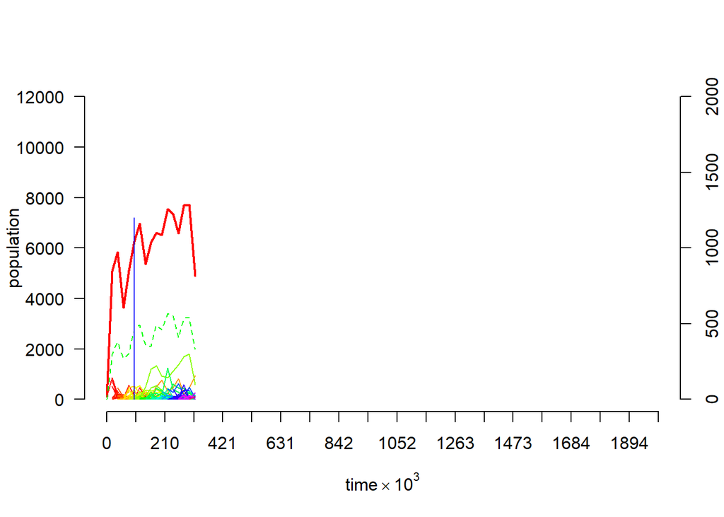

```r
source("../R/plot_onepop.R")

plot.onepop(sprintf("%spopdy001.dat",froot),"example1popdy.pdf",12,12,minpop=100, totpop=T,plotnspp = T)
segments(x0=100000,y0=0,y1=1200,col="blue")
```

the blue line indicates $t=100000$ - which is where the splist and out1 files explored below relate to.

Concerns: - this only records pop every 10000 timesteps - potentially many generations between recordings. Understandable though - if we find a particular feature, we can go back and rerun to get more detail. - Nothing here about species length - need to grab that info from the right spplists file - Need a sanity check on the species numbers via the spplists (since we are purging these).

# Community structure

## stats

### Stats from `splist` files

Theres a function called `splist_stats` that generates these - let’s check it out:

```r
source("../R/splist_stats.R")
sps <- splist_stats(sprintf("%ssplist100000.dat",froot),tmin=90000)
```

That works, so let’s see if we can do an iteration:

```r
gotdata<- T
tt <- 10000
while(gotdata){
  fn <- sprintf("%ssplist%d.dat",froot,tt)
  if(file.exists(fn)){
    message(sprintf("\nProcessing Time %d:",tt))
    splist_stats(fn,tmin=(tt-10000))
  }
  else
    gotdata <- F

  tt = tt+10000
}
```

That works as far as it goes, but we aren’t seeing the *dominant* reaction that we are looking for, just the “most common reaction that first occured withing 10000 time steps”.

### Stats from `.conf` files

If we want the commonest reaction at time x, we might be better to look at the out1*conf files - these are a snapshot of the current system by definition - these will take a little more work to interpret however, but they will be exact. We might even be able to use these to develop a network of what is going on…

Each entry for a reaction in the current state of the system looks like this:

```
%%% REACTION 718
REACTION
###############  8557 WWGEWLHHHRLUEUWJJJRNJXUUUDGRGJLRWWRE$BLUBO^B>C$=?>$$BLUBO%}OYHOB
REACTION_ACTIVE  8557 WWGEWLHHHRLUEUWJJJRNJXUUUDGRGJLRWWRE$BLUBO^B>C$=?>$$BLUBO%}OYHOBWWGEWLHHHRLUEUWJJJRNJXUUUDGRGJ irwf: 1 0 49 0 30 16 1 0 94 1 0 46 grid: 165 39  pass_index: 1629

PASSIVE
REACTION_PASSIVE 8557 WWGEWLHHHRLUEUWJJJRNJXUUUDGRGJLRWWRE$BLUBO^B>C$=?>$$BLUBO%}OYHOB grid: 166 40
###############  8557 WWGEWLHHHRLUEUWJJJRNJXUUUDGRGJLRWWRE$BLUBO^B>C$=?>$$BLUBO%}OYHOB

AGENT  JJRNJXUUUDGRHJLRWWRE$BLUBO^>C$=?>$$BUBOUB$=?>$$=?>$$BLUBO%}OYHOB 1 Q
GRIDPOS  190 30

AGENT  $BLUBO^>C$=?>$$BUBOUBO^B>C$=?>$$BLUBO%}OYHOB 1 Q
GRIDPOS  189 29
```

```r
require (stringr)
source("../R/splist_stats.R")

####Function 'arguments'
  fn <- sprintf("%sout1_100000.conf",froot)
  verbose <- T
  spldata <-  splist_stats(sprintf("%ssplist100000.dat",froot))

####Function 'body'

  cf <- read.table(fn,as.is = T, fill = T, sep="\n",comment.char="",stringsAsFactors = F)

  #get the row number of the start of each reaction entry
  rpos <- which(str_sub(cf[,1],1,12)=="%%% REACTION")

  nr <- length(rpos)
  actno <- vector(length = nr)
  actseq <- vector(length = nr)
  pasno <- vector(length = nr)
  passeq <- vector(length = nr)

  #build the data for each reaction - similar to the splist analysis
  for(rr in 1:nr){
    words <-strsplit(cf[rpos[rr]+2,1],split=" ")
    actno[rr] <- as.numeric(words[[1]][3])
    actseq[rr] <- words[[1]][4]
    words <-strsplit(cf[rpos[rr]+6,1],split=" ")
    pasno[rr] <- as.numeric(words[[1]][3])
    passeq[rr] <- words[[1]][4]
    #message(sprintf("Active  molecule %s seq %s",actno[rr],actseq[rr]))
    #message(sprintf("Passive molecule %s seq %s",actno[rr],actseq[rr]))
  }
  eachreaction<-data.frame(actno,actseq,pasno,passeq)

  reactions <- unique(eachreaction)
  reactions$type = "<unknown>"

  for(rr in 1:nrow(reactions)){
    ca <- eachreaction[eachreaction$actno == reactions$actno[rr] & eachreaction$pasno == reactions$pasno[rr],]
    reactions$count[rr] = nrow(ca)
  }
  reactions <- reactions[order(reactions$count,decreasing = T),]

  #Get the product molecule from the splist:
  for(rr in 1:nrow(reactions)){

    if(is.na(reactions$actno[rr]) || is.na(reactions$pasno[rr])){

        #message(sprintf("Reaction %d has NAs  (NA)",rr))
        reactions$type[rr]= "na"
        next
    }


    dd <- spldata[(spldata$act == reactions$actno[rr]) & (spldata$pass == reactions$pasno[rr]), ]
    if(nrow(dd)==0){
      #message(sprintf("Reaction %d has no product (NP)",rr))
      reactions$type[rr]= "NP"
    }
    if(reactions$actno[rr] == reactions$pasno[rr]){
      if(nrow(dd)==1){
        if(dd$spp == reactions$actno[rr]){
          #message(sprintf("Reaction %d is an exact self:self replicator (ER)*",rr))
          reactions$type[rr]= "ER"
        }
        else{
          #message(sprintf("Self:self reaction with different product (DP)*",rr))
          reactions$type[rr]= "DP"
        }
      }
      if(nrow(dd)>1){
        #message(sprintf("Reaction %d is a pathological replicator (PR)",rr))
        reactions$type[rr]= "PR"
      }
    }
    else{
      if(nrow(dd)==1){
        if(dd$spp == reactions$pasno[rr]){
          #message(sprintf("Reaction %d is parsitic (PA)*",rr))
        reactions$type[rr]= "PA"
        }
        else{
          #message(sprintf("non-self reaction with different product (DN)*",rr))
          reactions$type[rr]= "DN"
        }
      }
      if(nrow(dd)>1){
        #message(sprintf("Reaction %d is a pathological non-self replicator (PN)",rr))
        reactions$type[rr]= "PN"
      }
    }


  }
```

Check that we’ve now got this in a function:

```r
source("../R/splist_stats.R")
source("../R/rconf_stats.R")
source("../R/rconf_data.R")
reactions <- rconf_stats(fn = sprintf("%sout1_100000.conf",froot), spfn = sprintf("%ssplist100000.dat",froot))
```

Now we can count the different reaction types:

```r
rclass <- c("NA","NP","ER","DP","PR","PA","DN","PN")
rcounts <- data.frame(rclass)
for(rr in 1:length(rclass)){
  dd <- reactions[reactions$type == rclass[rr],]
  rcounts$count[rr] = nrow(dd)
}
```

That works, so let’s see if we can do an iteration:

```r
source("../R/splist_stats.R")
source("../R/rconf_stats.R")

gotdata<- T
tt <- 20000
#rcounts <- data.frame(rclass)
rcounts <- data.frame(time=0,"NA"=0,NP=0,ER=1,DP=0,PR=0,PA=0,DN=0,PN=0)
rsumcounts <- data.frame(time=0,"NA"=0,NP=0,ER=500,DP=0,PR=0,PA=0,DN=0,PN=0)
count <- vector(length = length(rclass))
scount <- vector(length = length(rclass))
count <- 0
sumcount <- 0
rno<-2

while(gotdata ){#&& tt < 320000){#
  fn <- sprintf("%ssplist%d.dat",froot,tt)
  spfn <- sprintf("%sout1_%d.dat",froot,tt)
  if(file.exists(fn)){
    message(sprintf("\nProcessing Time %d:",tt))
    reactions <- rconf_stats(fn = sprintf("%sout1_%d.conf",froot,tt), spfn = sprintf("%ssplist%d.dat",froot,tt),verbose=F)

    message("\n\nout\n\n")
    if(nrow(reactions)==0){
    }
    else{

      count <- 0
      sumcount <- 0

      for(rr in 1:length(rclass)){

        dd <- reactions[reactions$type == rclass[rr],]
        count[rr] <- nrow(dd)
        sumcount[rr] <- sum(dd$count)
      }
      #assign(sprintf("t%d",tt))

      trow = c(tt,t(count))
      rcounts <- rbind(rcounts,trow)

      trow = c(tt,t(sumcount))
      rsumcounts <- rbind(rsumcounts,trow)
      #colnames(rcounts)[rno] <- sprintf("t%d",tt)

      #rno <- rno + 1
    }

  }
  else{
    gotdata <- F
  }
  tt = tt+20000
  if(tt > 50000)gotdata <- F
}
```

```
##
## Processing Time 20000:
```

```
##
##
## out
```

```
##
## Processing Time 40000:
```

```
##
##
## out
```

```r
#Now we can plot the change in diversity:
#https://www.r-graph-gallery.com/stacked-barplot/
```

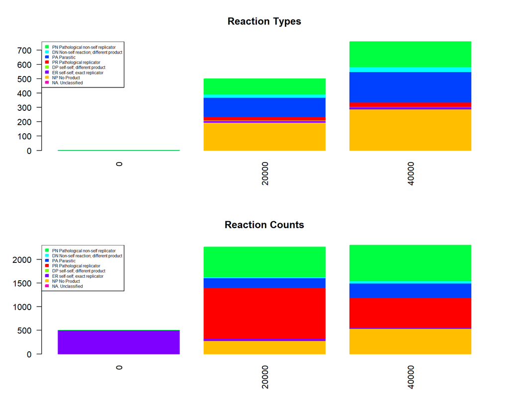

```r
bcols = rainbow(ncol(rcounts[2:9]))
bcols <- bcols[sample(1:length(bcols))]
par(mfrow=c(2,1))
barplot(t(rcounts[2:9]),col=bcols,border=bcols,names=rcounts[,1],las=2,main="Reaction Types")
cn <-colnames(rcounts)

#NB! This is not currently automatically ordered correctly..
cnlong <- c("Pathological non-self replicator",
            "Non-self reaction; different product",
            "Parasitic",
            "Pathological replicator",
            "self-self; different product",
            "self-self; exact replicator",
            "No Product",
            "Unclassified")

legend("topleft",legend=sprintf("%s %s",rev(cn[2:9]),cnlong),fill=rev(bcols),border=rev(bcols),cex = 0.5)

barplot(t(rsumcounts[2:9]),col=bcols,border=bcols,names=rcounts[,1],las=2,main="Reaction Counts")
cn <-colnames(rcounts)

legend("topleft",sprintf("%s %s",rev(cn[2:9]),cnlong),fill=rev(bcols),border=rev(bcols),cex = 0.5)
```

```r
#legend("topleft",legend=(cn[2:9]),fill=(bcols),border=(bcols))
```

## Handling the warnings…

let’s look at t=80000 again and make sure we are handling warnings properly.

```r
source("../R/splist_stats.R")
source("../R/rconf_data.R")
source("../R/rconf_stats.R")
tt <- 80000
spfn = sprintf("%ssplist%d.dat",froot,tt)
spldata <-  splist_stats(spfn)

fn = sprintf("%sout1_%d.conf",froot,tt)
#rcd <- rconf_rdata(fn,verbose=T)


reactions <- rconf_stats(fn, spfn, verbose = T)
```

```
## Loaded spldata using splist_stats
```

```
## Found 2177 reactions
```

```
## Bad format number 1 encountered
```

```
## Bad format number 2 encountered
```

```
## Bad format number 3 encountered
```

```
## Bad format number 4 encountered
```

```
## Reaction 1 seen 177 times
```

```
##
## 1
```

```
##
## 2
```

```
## Reaction 1 is a pathological replicator (PR)
```

```
##    Active  is 7220: $=?>$$BLUBO^B>C$=N?>$$BLUBO%}}Y^OB
```

```
##    Passive is 7220: $=?>$$BLUBO^B>C$=N?>$$BLUBO%}}Y^OB
```

```
## Reaction 2 seen 136 times
```

```
##
## 1
```

```
##
## 2
```

```
## Reaction 2 is a pathological replicator (PR)
```

```
##    Active  is 7380: WWGEWLHHHRLUEUWJJJRIUUUDYGRHJLRWWRE$BLUBO^B>C$=?>$$BLUBO%}OYHOB
```

```
##    Passive is 7380: WWGEWLHHHRLUEUWJJJRIUUUDYGRHJLRWWRE$BLUBO^B>C$=?>$$BLUBO%}OYHOB
```

```
## Reaction 3 seen 124 times
```

```
##
## 1
```

```
##
## 2
```

```
## Reaction 3 is a pathological replicator (PR)
```

```
##    Active  is 8044: WWGEWLHHHRLUEUWJJJRIUUUYGRHJLRWWRE$BLUBO^B>C$=?>$$BLUBO%}OYHOB
```

```
##    Passive is 8044: WWGEWLHHHRLUEUWJJJRIUUUYGRHJLRWWRE$BLUBO^B>C$=?>$$BLUBO%}OYHOB
```

```
## Reaction 4 seen 100 times
```

```
##
## 1
```

```
##
## 2
```

```
## Reaction 4 is a pathological replicator (PR)
```

```
##    Active  is 4545: EWLHHHRLUEUWJJYJRIXUUUYGRHJLRWWRE$BLUBO^B>C$=?>$$BLUBO%}OYHOB
```

```
##    Passive is 4545: EWLHHHRLUEUWJJYJRIXUUUYGRHJLRWWRE$BLUBO^B>C$=?>$$BLUBO%}OYHOB
```

```
## Reaction 5 seen 60 times
```

```
##
## 1
```

```
##
## 2
```

```
## Reaction 5 is a pathological non-self replicator (PN)
```

```
##    Active  is 7481: EWLHHHRLUEUWJJYJRJXUUYGRHJLRWWRE$BLUBO^B>C$=?>$$BLUBO%}OYHOB
```

```
##    Passive is 1390: HHRLUEUWJ
```

```
## Reaction 6 seen 53 times
```

```
##
## 1
```

```
##
## 2
```

```
## Reaction 6 is a pathological replicator (PR)
```

```
##    Active  is 6976: WWGEWLHHHRLUEUW>JJJSJXUUUDYRHJLRWWRE$BLUBO^B>C$=?>$$BLUBO%}OYHOB
```

```
##    Passive is 6976: WWGEWLHHHRLUEUW>JJJSJXUUUDYRHJLRWWRE$BLUBO^B>C$=?>$$BLUBO%}OYHOB
```

```
## Reaction 7 seen 37 times
```

```
##
## 1
```

```
##
## 2
```

```
## Reaction 7 is a pathological replicator (PR)
```

```
##    Active  is 8853: WWGEWLHHHRLUEUWJJJSJWUUUDXRHJLRWWRE$BLUBO^B>C$=?>$$BLUCO%}OYHOB
```

```
##    Passive is 8853: WWGEWLHHHRLUEUWJJJSJWUUUDXRHJLRWWRE$BLUBO^B>C$=?>$$BLUCO%}OYHOB
```

```
## Reaction 8 seen 34 times
```

```
##
## 1
```

```
##
## 2
```

```
## Reaction 8 is a pathological replicator (PR)
```

```
##    Active  is 808: $=?>$$
```

```
##    Passive is 808: $=?>$$
```

```
## Reaction 9 seen 31 times
```

```
##
## 1
```

```
##
## 2
```

```
## Reaction 9 is a pathological replicator (PR)
```

```
##    Active  is 8040: WWGEWLHHHRLUEUWJJJSJWUUUDYRHJLRWWRE$BLUBO^B>C$=?>$$BLUCO%}OYHOB
```

```
##    Passive is 8040: WWGEWLHHHRLUEUWJJJSJWUUUDYRHJLRWWRE$BLUBO^B>C$=?>$$BLUCO%}OYHOB
```

```
## Reaction 10 seen 30 times
```

```
##
## 1
```

```
##
## 2
```

```
## Reaction 10 is a pathological replicator (PR)
```

```
##    Active  is 7481: EWLHHHRLUEUWJJYJRJXUUYGRHJLRWWRE$BLUBO^B>C$=?>$$BLUBO%}OYHOB
```

```
##    Passive is 7481: EWLHHHRLUEUWJJYJRJXUUYGRHJLRWWRE$BLUBO^B>C$=?>$$BLUBO%}OYHOB
```

```
## Reaction 11 seen 29 times
```

```
##
## 1
```

```
##
## 2
```

```
## Reaction 11 is a pathological non-self replicator (PN)
```

```
##    Active  is 7220: $=?>$$BLUBO^B>C$=N?>$$BLUBO%}}Y^OB
```

```
##    Passive is 808: $=?>$$
```

```
## Reaction 12 seen 25 times
```

```
##
## 1
```

```
##
## 2
```

```
## Reaction 12 is a pathological replicator (PR)
```

```
##    Active  is 8789: WWGEWLHHHRLUEUWJJJRJUUDYGRHJLRWWRE$BLUBO^B>C$=?>$$CLUBO%}OYHOB
```

```
##    Passive is 8789: WWGEWLHHHRLUEUWJJJRJUUDYGRHJLRWWRE$BLUBO^B>C$=?>$$CLUBO%}OYHOB
```

```
## Reaction 13 seen 25 times
```

```
##
## 1
```

```
## Reaction 13 has no product (NP)
```

```
##    Active  is 5148: RJXUUUDYGRHJLRWWRE$BLUBPBLUBO^GB>C$=?>$$BLUBB>C$=?>$$BLUBOYHOBB
```

```
##    Passive is 5148: RJXUUUDYGRHJLRWWRE$BLUBPBLUBO^GB>C$=?>$$BLUBB>C$=?>$$BLUBOYHOBB
```

```
## Reaction 14 seen 23 times
```

```
##
## 1
```

```
##
## 2
```

```
## Reaction 14 is a pathological non-self replicator (PN)
```

```
##    Active  is 7380: WWGEWLHHHRLUEUWJJJRIUUUDYGRHJLRWWRE$BLUBO^B>C$=?>$$BLUBO%}OYHOB
```

```
##    Passive is 9289: WWGEWLHHHRLUEUWJJJRIUUUDYGHJLRWWRE$BLUBO^B>C$=?>$$BLUBO%}OYHOB
```

```
## Reaction 15 seen 19 times
```

```
##
## 1
```

```
## Reaction 15 has no product (NP)
```

```
##    Active  is 7681: JJRJXUUUDYG?RHJLRWWRE$BLUBOBLUBO^GB>C$=?>$$BLUBB>C$=?>$$BLUBOYHOBB
```

```
##    Passive is 7681: JJRJXUUUDYG?RHJLRWWRE$BLUBOBLUBO^GB>C$=?>$$BLUBB>C$=?>$$BLUBOYHOBB
```

```
## Reaction 16 seen 18 times
```

```
##
## 1
```

```
##
## 2
```

```
## Reaction 16 is a pathological non-self replicator (PN)
```

```
##    Active  is 8853: WWGEWLHHHRLUEUWJJJSJWUUUDXRHJLRWWRE$BLUBO^B>C$=?>$$BLUCO%}OYHOB
```

```
##    Passive is 3766: JXUUUDYGRHJLRWWRE$BLUBOBMUO^GB>C=?>$$BLUBB>C$=?>$$BLUBOYHOBB
```

```
## Reaction 17 seen 17 times
```

```
##
## 1
```

```
##
## 2
```

```
## Reaction 17 is a pathological non-self replicator (PN)
```

```
##    Active  is 8040: WWGEWLHHHRLUEUWJJJSJWUUUDYRHJLRWWRE$BLUBO^B>C$=?>$$BLUCO%}OYHOB
```

```
##    Passive is 8853: WWGEWLHHHRLUEUWJJJSJWUUUDXRHJLRWWRE$BLUBO^B>C$=?>$$BLUCO%}OYHOB
```

```
## Reaction 18 seen 15 times
```

```
##
## 1
```

```
## Reaction 18 has no product (NP)
```

```
##    Active  is 9184: UUDYGRHJLRWWRE$BLUBPBLUBO^GB>C$=?>$$BLUBB>C$=?>$$BLUBOYHOB
```

```
##    Passive is 9184: UUDYGRHJLRWWRE$BLUBPBLUBO^GB>C$=?>$$BLUBB>C$=?>$$BLUBOYHOB
```

```
## Reaction 19 seen 14 times
```

```
##
## 1
```

```
## Reaction 19 has no product (NP)
```

```
##    Active  is 1468: JJRJXUUUDYGRHJLRWWRE$BLUBOBLUBO^GB>C$=?>$$BLUBB>C$=?>$$BLUBOYHOBB
```

```
##    Passive is 1468: JJRJXUUUDYGRHJLRWWRE$BLUBOBLUBO^GB>C$=?>$$BLUBB>C$=?>$$BLUBOYHOBB
```

```
## Reaction 20 seen 14 times
```

```
##
## 1
```

```
## Reaction 20 has no product (NP)
```

```
##    Active  is 9289: WWGEWLHHHRLUEUWJJJRIUUUDYGHJLRWWRE$BLUBO^B>C$=?>$$BLUBO%}OYHOB
```

```
##    Passive is 9289: WWGEWLHHHRLUEUWJJJRIUUUDYGHJLRWWRE$BLUBO^B>C$=?>$$BLUBO%}OYHOB
```

```
## Reaction 21 seen 14 times
```

```
##
## 1
```

```
##
## 2
```

```
## Reaction 21 is a pathological replicator (PR)
```

```
##    Active  is 8115: UUDYGRHJLRWWRE$BLUBO^>C$=?>$$BLUBOHB>C$=N?>$$BLUBO%}}Y^OB
```

```
##    Passive is 8115: UUDYGRHJLRWWRE$BLUBO^>C$=?>$$BLUBOHB>C$=N?>$$BLUBO%}}Y^OB
```

```
## Reaction 22 seen 13 times
```

```
##
## 1
```

```
##
## 2
```

```
## Reaction 22 is a pathological non-self replicator (PN)
```

```
##    Active  is 8764: WWGEWLHHHRLUEUWJJRJUUUDYGRHJLRWWRE$BLUBO^B>C$=?>$$CLUBO%}OYHOB
```

```
##    Passive is 1390: HHRLUEUWJ
```

```
## Reaction 23 seen 13 times
```

```
##
## 1
```

```
## Reaction 23 has no product (NP)
```

```
##    Active  is 8690: JJRJXUUUDYG?RHJLRWWRE$BLUBOBLUBGO^GB>C$=?>$$BLUBB>C$=?>$$BLUBOYHOBB
```

```
##    Passive is 8690: JJRJXUUUDYG?RHJLRWWRE$BLUBOBLUBGO^GB>C$=?>$$BLUBB>C$=?>$$BLUBOYHOBB
```

```
## Reaction 24 seen 13 times
```

```
##
## 1
```

```
##
## 2
```

```
## Reaction 24 is a pathological replicator (PR)
```

```
##    Active  is 9627: WWGEWLHHHRLUEUWNJJJRJUUDYGRHJLRWWRE$BLUBO^B>C$=?>$$CLUBO%}OYHOB
```

```
##    Passive is 9627: WWGEWLHHHRLUEUWNJJJRJUUDYGRHJLRWWRE$BLUBO^B>C$=?>$$CLUBO%}OYHOB
```

```
## Reaction 25 seen 12 times
```

```
##
## 1
```

```
##
## 2
```

```
## Reaction 25 is a pathological replicator (PR)
```

```
##    Active  is 7249: EWLHHHRLUEUWJYJRIXUUUYGRHJLRWWRE$BLUBO^B>C$=?>$$BLUBO%}OYHOB
```

```
##    Passive is 7249: EWLHHHRLUEUWJYJRIXUUUYGRHJLRWWRE$BLUBO^B>C$=?>$$BLUBO%}OYHOB
```

```
## Reaction 26 seen 12 times
```

```
##
## 1
```

```
##
## 2
```

```
## Reaction 26 is a pathological non-self replicator (PN)
```

```
##    Active  is 7380: WWGEWLHHHRLUEUWJJJRIUUUDYGRHJLRWWRE$BLUBO^B>C$=?>$$BLUBO%}OYHOB
```

```
##    Passive is 8044: WWGEWLHHHRLUEUWJJJRIUUUYGRHJLRWWRE$BLUBO^B>C$=?>$$BLUBO%}OYHOB
```

```
## Reaction 27 seen 11 times
```

```
##
## 1
```

```
##
## 2
```

```
## Reaction 27 is a pathological non-self replicator (PN)
```

```
##    Active  is 6381: WWGEWLHHHRLUEUWJJJSJXUUUDYHJLRWWRE$BLUBO^B>C$=?>$$BLUBO%}OYHOB
```

```
##    Passive is 4838: UUDYGRHJLRWWRE$BLUBOBLUO^GB>C$=?>$$BLUBB>C$=?>$$BLUBOYHOBB
```

```
## Reaction 28 seen 11 times
```

```
##
## 1
```

```
##
## 2
```

```
## Reaction 28 is a pathological non-self replicator (PN)
```

```
##    Active  is 7380: WWGEWLHHHRLUEUWJJJRIUUUDYGRHJLRWWRE$BLUBO^B>C$=?>$$BLUBO%}OYHOB
```

```
##    Passive is 9506: WWGEWLHHHRLUEUWJJJRIUUUDYGRHJLRWWRE$BLUAO^B>C$=?>$$BLUBO%}OYHOB
```

```
## Reaction 29 seen 11 times
```

```
##
## 1
```

```
##
## 2
```

```
## Reaction 29 is a pathological non-self replicator (PN)
```

```
##    Active  is 7380: WWGEWLHHHRLUEUWJJJRIUUUDYGRHJLRWWRE$BLUBO^B>C$=?>$$BLUBO%}OYHOB
```

```
##    Passive is 8115: UUDYGRHJLRWWRE$BLUBO^>C$=?>$$BLUBOHB>C$=N?>$$BLUBO%}}Y^OB
```

```
## Reaction 30 seen 11 times
```

```
##
## 1
```

```
##
## 2
```

```
## Reaction 30 is a pathological non-self replicator (PN)
```

```
##    Active  is 8195: WWGEWLHHHRLUEUWJJJRJUUUDYGRHJLSRWWRE$BLUBO^B>CW$=?>$$BLUBO%}OYHOB
```

```
##    Passive is 1390: HHRLUEUWJ
```

```
## Reaction 31 seen 11 times
```

```
##
## 1
```

```
##
## 2
```

```
## Reaction 31 is a pathological replicator (PR)
```

```
##    Active  is 8839: HHHRLUEUWJJJRIUUUDYGRHJLRWWRE$BLUBO^B>C$=?>$$BLUBO%}OYHOB
```

```
##    Passive is 8839: HHHRLUEUWJJJRIUUUDYGRHJLRWWRE$BLUBO^B>C$=?>$$BLUBO%}OYHOB
```

```
## Reaction 32 seen 11 times
```

```
##
## 1
```

```
## Reaction 32 has no product (NP)
```

```
##    Active  is 6684: JXUUUDYGRHJLRWWRE$BLUBOBLUBO^GB>C$=?>$$BLUBB>C$=?>$$BLUBOYHOBB
```

```
##    Passive is 6684: JXUUUDYGRHJLRWWRE$BLUBOBLUBO^GB>C$=?>$$BLUBB>C$=?>$$BLUBOYHOBB
```

```
## Reaction 33 seen 10 times
```

```
##
## 1
```

```
## Reaction 33 has no product (NP)
```

```
##    Active  is 1796: UUDYGSHJLRWWRE$BLUBOBLUBO^G>C$=?>$$BLUBB>C$=?>$$BLUBOYHOBB
```

```
##    Passive is 1796: UUDYGSHJLRWWRE$BLUBOBLUBO^G>C$=?>$$BLUBB>C$=?>$$BLUBOYHOBB
```

```
## Reaction 34 seen 10 times
```

```
##
## 1
```

```
##
## 2
```

```
## Reaction 34 is a pathological non-self replicator (PN)
```

```
##    Active  is 8794: EWLHHHRLUEUWJJYJRJXUUYGSHJLRWWRE$BLUBO^B>C$=?>$$BLUBO%}OYHOB
```

```
##    Passive is 1390: HHRLUEUWJ
```

```
## Reaction 35 seen 10 times
```

```
##
## 1
```

```
##
## 2
```

```
## Reaction 35 is a pathological non-self replicator (PN)
```

```
##    Active  is 6550: WWGEWLHHHRLUEUWJJJRJUUUDYGRHJLSRWWRE$BLUBO^B>C$=?>$$BLUBO%}OYHOB
```

```
##    Passive is 6684: JXUUUDYGRHJLRWWRE$BLUBOBLUBO^GB>C$=?>$$BLUBB>C$=?>$$BLUBOYHOBB
```

```
## Reaction 36 seen 10 times
```

```
##
## 1
```

```
##
## 2
```

```
## Reaction 36 is a pathological non-self replicator (PN)
```

```
##    Active  is 1468: JJRJXUUUDYGRHJLRWWRE$BLUBOBLUBO^GB>C$=?>$$BLUBB>C$=?>$$BLUBOYHOBB
```

```
##    Passive is 8044: WWGEWLHHHRLUEUWJJJRIUUUYGRHJLRWWRE$BLUBO^B>C$=?>$$BLUBO%}OYHOB
```

```
## Reaction 37 seen 10 times
```

```
##
## 1
```

```
##
## 2
```

```
## Reaction 37 is a pathological replicator (PR)
```

```
##    Active  is 8457: EWLHHHRLUEUWKJYJRIXUUUYGRHJLRWWRE$BLUBO^B>C$=?>$$BLUBO%}OYHOB
```

```
##    Passive is 8457: EWLHHHRLUEUWKJYJRIXUUUYGRHJLRWWRE$BLUBO^B>C$=?>$$BLUBO%}OYHOB
```

```
## Reaction 38 seen 9 times
```

```
##
## 1
```

```
## Reaction 38 has no product (NP)
```

```
##    Active  is 3766: JXUUUDYGRHJLRWWRE$BLUBOBMUO^GB>C=?>$$BLUBB>C$=?>$$BLUBOYHOBB
```

```
##    Passive is 3766: JXUUUDYGRHJLRWWRE$BLUBOBMUO^GB>C=?>$$BLUBB>C$=?>$$BLUBOYHOBB
```

```
## Reaction 39 seen 9 times
```

```
##
## 1
```

```
##
## 2
```

```
## Reaction 39 is a pathological non-self replicator (PN)
```

```
##    Active  is 8769: RJXUUYGRHJLRWWRE$BLUBO^B>C$=?>$$BLUBO%}OYHOB
```

```
##    Passive is 1390: HHRLUEUWJ
```

```
## Reaction 40 seen 9 times
```

```
##
## 1
```

```
##
## 2
```

```
## Reaction 40 is a pathological non-self replicator (PN)
```

```
##    Active  is 8044: WWGEWLHHHRLUEUWJJJRIUUUYGRHJLRWWRE$BLUBO^B>C$=?>$$BLUBO%}OYHOB
```

```
##    Passive is 9066: WWGEWLHHHRLUEUWJJJRIUUUYGRHJLRWWRE$CLUBO^B>C$=?>$$BLUBO%}OYHOB
```

```
## Reaction 41 seen 8 times
```

```
##
## 1
```

```
##
## 2
```

```
## none-self reaction with different product (DN)*
```

```
##    Active  is 9184: UUDYGRHJLRWWRE$BLUBPBLUBO^GB>C$=?>$$BLUBB>C$=?>$$BLUBOYHOB
```

```
##    Passive is 1390: HHRLUEUWJ
```

```
## Reaction 42 seen 8 times
```

```
##
## 1
```

```
##
## 2
```

```
## Reaction 42 is a pathological replicator (PR)
```

```
##    Active  is 9043: EWLHHHRLUEUWJJYJRIXUUUYGRHJLRWXRE$BLUBO^B>C$=?>$$BLUBO%}OYHOB
```

```
##    Passive is 9043: EWLHHHRLUEUWJJYJRIXUUUYGRHJLRWXRE$BLUBO^B>C$=?>$$BLUBO%}OYHOB
```

```
## Reaction 43 seen 8 times
```

```
##
## 1
```

```
##
## 2
```

```
## Reaction 43 is parsitic (PA)*
```

```
##    Active  is 8044: WWGEWLHHHRLUEUWJJJRIUUUYGRHJLRWWRE$BLUBO^B>C$=?>$$BLUBO%}OYHOB
```

```
##    Passive is 9573: WWGEWLHHHRLUEUWJJJRJU=DYGRHJLRWWRE$BLUBO^B>C$=?>$$CLUBO%}OYHOB
```

```
## Reaction 44 seen 8 times
```

```
##
## 1
```

```
## Reaction 44 has no product (NP)
```

```
##    Active  is 7523: UUDYGRHJLRWWRE$BLUBPBLUBO^GB>C$=?>$$BLUBB>C$=?>$$BLUBOYHOBB
```

```
##    Passive is 7523: UUDYGRHJLRWWRE$BLUBPBLUBO^GB>C$=?>$$BLUBB>C$=?>$$BLUBOYHOBB
```

```
## Reaction 45 seen 8 times
```

```
##
## 1
```

```
##
## 2
```

```
## Reaction 45 is a pathological non-self replicator (PN)
```

```
##    Active  is 4545: EWLHHHRLUEUWJJYJRIXUUUYGRHJLRWWRE$BLUBO^B>C$=?>$$BLUBO%}OYHOB
```

```
##    Passive is 1390: HHRLUEUWJ
```

```
## Reaction 46 seen 7 times
```

```
##
## 1
```

```
##
## 2
```

```
## Reaction 46 is a pathological non-self replicator (PN)
```

```
##    Active  is 8044: WWGEWLHHHRLUEUWJJJRIUUUYGRHJLRWWRE$BLUBO^B>C$=?>$$BLUBO%}OYHOB
```

```
##    Passive is 8985: UUDYGRHJLRWWRE$BLUBO^>C$=?>$$BLUBO^B>C$=N?>$$BUBO%}OY^OB
```

```
## Reaction 47 seen 7 times
```

```
##
## 1
```

```
##
## 2
```

```
## Reaction 47 is parsitic (PA)*
```

```
##    Active  is 7481: EWLHHHRLUEUWJJYJRJXUUYGRHJLRWWRE$BLUBO^B>C$=?>$$BLUBO%}OYHOB
```

```
##    Passive is 9184: UUDYGRHJLRWWRE$BLUBPBLUBO^GB>C$=?>$$BLUBB>C$=?>$$BLUBOYHOB
```

```
## Reaction 48 seen 7 times
```

```
##
## 1
```

```
##
## 2
```

```
## Reaction 48 is parsitic (PA)*
```

```
##    Active  is 8662: WWGEWLHHHRLUEUWJJJRJUUUDYGRHJLRWWRE$BLUBO^B>C$=?>$$CLUBO%}OYHOB
```

```
##    Passive is 9627: WWGEWLHHHRLUEUWNJJJRJUUDYGRHJLRWWRE$BLUBO^B>C$=?>$$CLUBO%}OYHOB
```

```
## Reaction 49 seen 7 times
```

```
##
## 1
```

```
##
## 2
```

```
## Reaction 49 is a pathological replicator (PR)
```

```
##    Active  is 195: WWGEWLHHHRLUEUWJJJSJXUUUDYRHJLRWWRE$BLUBO^B>C$=?>$$BLUBO%}OYHOB
```

```
##    Passive is 195: WWGEWLHHHRLUEUWJJJSJXUUUDYRHJLRWWRE$BLUBO^B>C$=?>$$BLUBO%}OYHOB
```

```
## Reaction 50 seen 7 times
```

```
##
## 1
```

```
##
## 2
```

```
## Reaction 50 is parsitic (PA)*
```

```
##    Active  is 7380: WWGEWLHHHRLUEUWJJJRIUUUDYGRHJLRWWRE$BLUBO^B>C$=?>$$BLUBO%}OYHOB
```

```
##    Passive is 3766: JXUUUDYGRHJLRWWRE$BLUBOBMUO^GB>C=?>$$BLUBB>C$=?>$$BLUBOYHOBB
```

```
## Reaction 51 seen 6 times
```

```
##
## 1
```

```
##
## 2
```

```
## Reaction 51 is a pathological non-self replicator (PN)
```

```
##    Active  is 4545: EWLHHHRLUEUWJJYJRIXUUUYGRHJLRWWRE$BLUBO^B>C$=?>$$BLUBO%}OYHOB
```

```
##    Passive is 9043: EWLHHHRLUEUWJJYJRIXUUUYGRHJLRWXRE$BLUBO^B>C$=?>$$BLUBO%}OYHOB
```

```
## Reaction 52 seen 6 times
```

```
##
## 1
```

```
##
## 2
```

```
## Reaction 52 is parsitic (PA)*
```

```
##    Active  is 6976: WWGEWLHHHRLUEUW>JJJSJXUUUDYRHJLRWWRE$BLUBO^B>C$=?>$$BLUBO%}OYHOB
```

```
##    Passive is 9593: WWGEWLHHHRLUEUW>JJJSJXUUUDYRHJLRWWRE$BLUBO^B>C
```

```
## Reaction 53 seen 6 times
```

```
##
## 1
```

```
##
## 2
```

```
## Reaction 53 is a pathological non-self replicator (PN)
```

```
##    Active  is 4545: EWLHHHRLUEUWJJYJRIXUUUYGRHJLRWWRE$BLUBO^B>C$=?>$$BLUBO%}OYHOB
```

```
##    Passive is 9870: EWLHHHRLUEUWJJYJRIXUUUYGHJLRWWRE$OYHOB
```

```
## Reaction 54 seen 6 times
```

```
##
## 1
```

```
##
## 2
```

```
## Reaction 54 is a pathological non-self replicator (PN)
```

```
##    Active  is 8040: WWGEWLHHHRLUEUWJJJSJWUUUDYRHJLRWWRE$BLUBO^B>C$=?>$$BLUCO%}OYHOB
```

```
##    Passive is 3766: JXUUUDYGRHJLRWWRE$BLUBOBMUO^GB>C=?>$$BLUBB>C$=?>$$BLUBOYHOBB
```

```
## Reaction 55 seen 6 times
```

```
##
## 1
```

```
##
## 2
```

```
## Reaction 55 is a pathological non-self replicator (PN)
```

```
##    Active  is 4545: EWLHHHRLUEUWJJYJRIXUUUYGRHJLRWWRE$BLUBO^B>C$=?>$$BLUBO%}OYHOB
```

```
##    Passive is 9460: UUDYGRHJLRWWRE$BLUBPBLUBO^GB>C$=?>$$BLUBB>C$=?>$$BLUBOY^OBB
```

```
## Reaction 56 seen 6 times
```

```
##
## 1
```

```
##
## 2
```

```
## Reaction 56 is a pathological non-self replicator (PN)
```

```
##    Active  is 8195: WWGEWLHHHRLUEUWJJJRJUUUDYGRHJLSRWWRE$BLUBO^B>CW$=?>$$BLUBO%}OYHOB
```

```
##    Passive is 8009: WWGEWLHHHLUEUWJJJRJXUUDYGORHJLRWWRE$OYHOB
```

```
## Reaction 57 seen 6 times
```

```
##
## 1
```

```
## Reaction 57 has no product (NP)
```

```
##    Active  is 8850: RJXUUUDYGRHJLRWWRE$BLUBPBLUBO^GB>C$=?>$$BLUBB>C$=?>$$BLUBOY^OBB
```

```
##    Passive is 8850: RJXUUUDYGRHJLRWWRE$BLUBPBLUBO^GB>C$=?>$$BLUBB>C$=?>$$BLUBOY^OBB
```

```
## Reaction 58 seen 6 times
```

```
##
## 1
```

```
##
## 2
```

```
## Reaction 58 is a pathological non-self replicator (PN)
```

```
##    Active  is 6976: WWGEWLHHHRLUEUW>JJJSJXUUUDYRHJLRWWRE$BLUBO^B>C$=?>$$BLUBO%}OYHOB
```

```
##    Passive is 195: WWGEWLHHHRLUEUWJJJSJXUUUDYRHJLRWWRE$BLUBO^B>C$=?>$$BLUBO%}OYHOB
```

```
## Reaction 59 seen 6 times
```

```
##
## 1
```

```
##
## 2
```

```
## Reaction 59 is a pathological non-self replicator (PN)
```

```
##    Active  is 7493: WWGEWLHHHRLUEUWJJJRJUUUDYGSHJLRWWRE$BLUBO^B>C$=?>$$BLUBO%}OYHOB
```

```
##    Passive is 1390: HHRLUEUWJ
```

```
## Reaction 60 seen 6 times
```

```
##
## 1
```

```
##
## 2
```

```
## Reaction 60 is a pathological non-self replicator (PN)
```

```
##    Active  is 8195: WWGEWLHHHRLUEUWJJJRJUUUDYGRHJLSRWWRE$BLUBO^B>CW$=?>$$BLUBO%}OYHOB
```

```
##    Passive is 6684: JXUUUDYGRHJLRWWRE$BLUBOBLUBO^GB>C$=?>$$BLUBB>C$=?>$$BLUBOYHOBB
```

```
## Reaction 61 seen 5 times
```

```
##
## 1
```

```
## Reaction 61 has no product (NP)
```

```
##    Active  is 9870: EWLHHHRLUEUWJJYJRIXUUUYGHJLRWWRE$OYHOB
```

```
##    Passive is 9870: EWLHHHRLUEUWJJYJRIXUUUYGHJLRWWRE$OYHOB
```

```
## Reaction 62 seen 5 times
```

```
##
## 1
```

```
##
## 2
```

```
## Reaction 62 is a pathological non-self replicator (PN)
```

```
##    Active  is 6669: WWGEWLHHHRLUEUWJJJSJXUUUUDYRHJLRWWRE$BLUBO^B>C$=?>$$BLUBO%}OYHOB
```

```
##    Passive is 3955: UUUDYGSHJLRWWRE$BLUBOBLUBO^G>C$=?>$$BLUBB>C$=?>$$BLUBOYHOBB
```

```
## Reaction 63 seen 5 times
```

```
##
## 1
```

```
##
## 2
```

```
## Reaction 63 is a pathological non-self replicator (PN)
```

```
##    Active  is 8457: EWLHHHRLUEUWKJYJRIXUUUYGRHJLRWWRE$BLUBO^B>C$=?>$$BLUBO%}OYHOB
```

```
##    Passive is 4545: EWLHHHRLUEUWJJYJRIXUUUYGRHJLRWWRE$BLUBO^B>C$=?>$$BLUBO%}OYHOB
```

```
## Reaction 64 seen 5 times
```

```
##
## 1
```

```
##
## 2
```

```
## Reaction 64 is parsitic (PA)*
```

```
##    Active  is 9066: WWGEWLHHHRLUEUWJJJRIUUUYGRHJLRWWRE$CLUBO^B>C$=?>$$BLUBO%}OYHOB
```

```
##    Passive is 9800: WWGEWLHHHRLUEUWJKJRIUUUYGRHJLRWWRE$BLUBO^B>C$=?>$$BLUBO%}OYHOB
```

```
## Reaction 65 seen 5 times
```

```
##
## 1
```

```
##
## 2
```

```
## Reaction 65 is a pathological non-self replicator (PN)
```

```
##    Active  is 5148: RJXUUUDYGRHJLRWWRE$BLUBPBLUBO^GB>C$=?>$$BLUBB>C$=?>$$BLUBOYHOBB
```

```
##    Passive is 4545: EWLHHHRLUEUWJJYJRIXUUUYGRHJLRWWRE$BLUBO^B>C$=?>$$BLUBO%}OYHOB
```

```
## Reaction 66 seen 5 times
```

```
##
## 1
```

```
##
## 2
```

```
## Reaction 66 is a pathological non-self replicator (PN)
```

```
##    Active  is 4545: EWLHHHRLUEUWJJYJRIXUUUYGRHJLRWWRE$BLUBO^B>C$=?>$$BLUBO%}OYHOB
```

```
##    Passive is 5148: RJXUUUDYGRHJLRWWRE$BLUBPBLUBO^GB>C$=?>$$BLUBB>C$=?>$$BLUBOYHOBB
```

```
## Reaction 67 seen 5 times
```

```
##
## 1
```

```
## Reaction 67 has no product (NP)
```

```
##    Active  is 7130: JJRJXUUUDYGRGJLRWWRE$BLUBOBLUO^GB>C$=?>$$BLUBQB>C$=?>$$BLUBOYHOBBB
```

```
##    Passive is 7130: JJRJXUUUDYGRGJLRWWRE$BLUBOBLUO^GB>C$=?>$$BLUBQB>C$=?>$$BLUBOYHOBBB
```

```
## Reaction 68 seen 5 times
```

```
##
## 1
```

```
##
## 2
```

```
## Reaction 68 is a pathological replicator (PR)
```

```
##    Active  is 8764: WWGEWLHHHRLUEUWJJRJUUUDYGRHJLRWWRE$BLUBO^B>C$=?>$$CLUBO%}OYHOB
```

```
##    Passive is 8764: WWGEWLHHHRLUEUWJJRJUUUDYGRHJLRWWRE$BLUBO^B>C$=?>$$CLUBO%}OYHOB
```

```
## Reaction 69 seen 5 times
```

```
##
## 1
```

```
##
## 2
```

```
## Reaction 69 is a pathological non-self replicator (PN)
```

```
##    Active  is 4545: EWLHHHRLUEUWJJYJRIXUUUYGRHJLRWWRE$BLUBO^B>C$=?>$$BLUBO%}OYHOB
```

```
##    Passive is 8457: EWLHHHRLUEUWKJYJRIXUUUYGRHJLRWWRE$BLUBO^B>C$=?>$$BLUBO%}OYHOB
```

```
## Reaction 70 seen 5 times
```

```
##
## 1
```

```
##
## 2
```

```
## Reaction 70 is a pathological non-self replicator (PN)
```

```
##    Active  is 8839: HHHRLUEUWJJJRIUUUDYGRHJLRWWRE$BLUBO^B>C$=?>$$BLUBO%}OYHOB
```

```
##    Passive is 9289: WWGEWLHHHRLUEUWJJJRIUUUDYGHJLRWWRE$BLUBO^B>C$=?>$$BLUBO%}OYHOB
```

```
## Reaction 71 seen 5 times
```

```
##
## 1
```

```
##
## 2
```

```
## Reaction 71 is a pathological non-self replicator (PN)
```

```
##    Active  is 8044: WWGEWLHHHRLUEUWJJJRIUUUYGRHJLRWWRE$BLUBO^B>C$=?>$$BLUBO%}OYHOB
```

```
##    Passive is 808: $=?>$$
```

```
## Reaction 72 seen 5 times
```

```
##
## 1
```

```
##
## 2
```

```
## Reaction 72 is parsitic (PA)*
```

```
##    Active  is 9289: WWGEWLHHHRLUEUWJJJRIUUUDYGHJLRWWRE$BLUBO^B>C$=?>$$BLUBO%}OYHOB
```

```
##    Passive is 8115: UUDYGRHJLRWWRE$BLUBO^>C$=?>$$BLUBOHB>C$=N?>$$BLUBO%}}Y^OB
```

```
## Reaction 73 seen 5 times
```

```
##
## 1
```

```
##
## 2
```

```
## Reaction 73 is a pathological non-self replicator (PN)
```

```
##    Active  is 6550: WWGEWLHHHRLUEUWJJJRJUUUDYGRHJLSRWWRE$BLUBO^B>C$=?>$$BLUBO%}OYHOB
```

```
##    Passive is 7481: EWLHHHRLUEUWJJYJRJXUUYGRHJLRWWRE$BLUBO^B>C$=?>$$BLUBO%}OYHOB
```

```
## Reaction 74 seen 5 times
```

```
##
## 1
```

```
##
## 2
```

```
## Reaction 74 is parsitic (PA)*
```

```
##    Active  is 8789: WWGEWLHHHRLUEUWJJJRJUUDYGRHJLRWWRE$BLUBO^B>C$=?>$$CLUBO%}OYHOB
```

```
##    Passive is 9662: WWGEWLHHHRLUEUWJJJRJUUDYGRHYJLRWWRE$BLUBO^B>C$=?>$$CLUBO%}OYHOB
```

```
## Reaction 75 seen 4 times
```

```
##
## 1
```

```
##
## 2
```

```
## Reaction 75 is a pathological non-self replicator (PN)
```

```
##    Active  is 9234: WWGEWLHHHRLUEUWJJJRJUUUDZGRHJLRWWRE$BLUBO^B>C$=?>$$BLUBO%}OYHOB
```

```
##    Passive is 1390: HHRLUEUWJ
```

```
## Reaction 76 seen 4 times
```

```
##
## 1
```

```
##
## 2
```

```
## Reaction 76 is a pathological non-self replicator (PN)
```

```
##    Active  is 9066: WWGEWLHHHRLUEUWJJJRIUUUYGRHJLRWWRE$CLUBO^B>C$=?>$$BLUBO%}OYHOB
```

```
##    Passive is 8044: WWGEWLHHHRLUEUWJJJRIUUUYGRHJLRWWRE$BLUBO^B>C$=?>$$BLUBO%}OYHOB
```

```
## Reaction 77 seen 4 times
```

```
##
## 1
```

```
##
## 2
```

```
## Reaction 77 is a pathological non-self replicator (PN)
```

```
##    Active  is 8872: WWGEWLHHHRLUEUWJJJSJX=UUDYHJLRWWRE$BLUBO^B>C$=?>$$BLUBO%}OYHOB
```

```
##    Passive is 9030: UUDYGRHJLRWWRE$BLUBOBLUO^GB>C$=?>$$BLUBB>C$=?>$DCLUBOYHOBB
```

```
## Reaction 78 seen 4 times
```

```
##
## 1
```

```
##
## 2
```

```
## Reaction 78 is a pathological non-self replicator (PN)
```

```
##    Active  is 8853: WWGEWLHHHRLUEUWJJJSJWUUUDXRHJLRWWRE$BLUBO^B>C$=?>$$BLUCO%}OYHOB
```

```
##    Passive is 9385: WWGEWLHHHRMUEUWJJJSJWUUUDXRHJLRWWRE$BLUBO^B>C$=?>$$BLUCO%}OYHOB
```

```
## Reaction 79 seen 4 times
```

```
##
## 1
```

```
##
## 2
```

```
## Reaction 79 is a pathological non-self replicator (PN)
```

```
##    Active  is 8195: WWGEWLHHHRLUEUWJJJRJUUUDYGRHJLSRWWRE$BLUBO^B>CW$=?>$$BLUBO%}OYHOB
```

```
##    Passive is 6550: WWGEWLHHHRLUEUWJJJRJUUUDYGRHJLSRWWRE$BLUBO^B>C$=?>$$BLUBO%}OYHOB
```

```
## Reaction 80 seen 4 times
```

```
##
## 1
```

```
##
## 2
```

```
## Reaction 80 is a pathological non-self replicator (PN)
```

```
##    Active  is 808: $=?>$$
```

```
##    Passive is 7220: $=?>$$BLUBO^B>C$=N?>$$BLUBO%}}Y^OB
```

```
## Reaction 81 seen 4 times
```

```
##
## 1
```

```
##
## 2
```

```
## Reaction 81 is parsitic (PA)*
```

```
##    Active  is 8044: WWGEWLHHHRLUEUWJJJRIUUUYGRHJLRWWRE$BLUBO^B>C$=?>$$BLUBO%}OYHOB
```

```
##    Passive is 9800: WWGEWLHHHRLUEUWJKJRIUUUYGRHJLRWWRE$BLUBO^B>C$=?>$$BLUBO%}OYHOB
```

```
## Reaction 82 seen 4 times
```

```
##
## 1
```

```
##
## 2
```

```
## Reaction 82 is a pathological non-self replicator (PN)
```

```
##    Active  is 7481: EWLHHHRLUEUWJJYJRJXUUYGRHJLRWWRE$BLUBO^B>C$=?>$$BLUBO%}OYHOB
```

```
##    Passive is 6684: JXUUUDYGRHJLRWWRE$BLUBOBLUBO^GB>C$=?>$$BLUBB>C$=?>$$BLUBOYHOBB
```

```
## Reaction 83 seen 4 times
```

```
##
## 1
```

```
##
## 2
```

```
## Reaction 83 is a pathological non-self replicator (PN)
```

```
##    Active  is 4545: EWLHHHRLUEUWJJYJRIXUUUYGRHJLRWWRE$BLUBO^B>C$=?>$$BLUBO%}OYHOB
```

```
##    Passive is 9600: EWLHHHRLUEUWAJJYJRIXUUUYGRHJLRWWRE$BLUBO^B>C$=?>$$BLUBO%}OYHOB
```

```
## Reaction 84 seen 4 times
```

```
##
## 1
```

```
## Reaction 84 has no product (NP)
```

```
##    Active  is 9446: JJRJXUUUDYG?RHJLRWWRE$BLUBOLUBO^GB>C$=?>$$BLUBB>C$=?>$$BLUBOYHOBB
```

```
##    Passive is 9446: JJRJXUUUDYG?RHJLRWWRE$BLUBOLUBO^GB>C$=?>$$BLUBB>C$=?>$$BLUBOYHOBB
```

```
## Reaction 85 seen 4 times
```

```
##
## 1
```

```
##
## 2
```

```
## Reaction 85 is a pathological non-self replicator (PN)
```

```
##    Active  is 6979: EWLHHHRLUEUWJJYJRJXUUYGRHJLRWXRE$BLUBO^B>C$=?>$$BLUBO%}OYHOB
```

```
##    Passive is 8183: UUDYHSHJLRWWRE$BLUBOBLUBO^G>C$=?>$$BLUBB>C$=?>$$BLUBOYHOBB
```

```
## Reaction 86 seen 4 times
```

```
##
## 1
```

```
## Reaction 86 has no product (NP)
```

```
##    Active  is 9030: UUDYGRHJLRWWRE$BLUBOBLUO^GB>C$=?>$$BLUBB>C$=?>$DCLUBOYHOBB
```

```
##    Passive is 9030: UUDYGRHJLRWWRE$BLUBOBLUO^GB>C$=?>$$BLUBB>C$=?>$DCLUBOYHOBB
```

```
## Reaction 87 seen 4 times
```

```
##
## 1
```

```
##
## 2
```

```
## none-self reaction with different product (DN)*
```

```
##    Active  is 8642: $=?>$$BLUBO^B>C=N?>$$BLUBO%}}Y^OB$
```

```
##    Passive is 7220: $=?>$$BLUBO^B>C$=N?>$$BLUBO%}}Y^OB
```

```
## Reaction 88 seen 4 times
```

```
##
## 1
```

```
##
## 2
```

```
## Reaction 88 is parsitic (PA)*
```

```
##    Active  is 7249: EWLHHHRLUEUWJYJRIXUUUYGRHJLRWWRE$BLUBO^B>C$=?>$$BLUBO%}OYHOB
```

```
##    Passive is 4545: EWLHHHRLUEUWJJYJRIXUUUYGRHJLRWWRE$BLUBO^B>C$=?>$$BLUBO%}OYHOB
```

```
## Reaction 89 seen 4 times
```

```
##
## 1
```

```
##
## 2
```

```
## Reaction 89 is a pathological non-self replicator (PN)
```

```
##    Active  is 4545: EWLHHHRLUEUWJJYJRIXUUUYGRHJLRWWRE$BLUBO^B>C$=?>$$BLUBO%}OYHOB
```

```
##    Passive is 7481: EWLHHHRLUEUWJJYJRJXUUYGRHJLRWWRE$BLUBO^B>C$=?>$$BLUBO%}OYHOB
```

```
## Reaction 90 seen 4 times
```

```
##
## 1
```

```
##
## 2
```

```
## none-self reaction with different product (DN)*
```

```
##    Active  is 9923: UUDYG?RHJLRWWRE$BLUBOBLUBO^GB>C$=?>$$BMUBB>C$=?>$$BLUBOYHOBB
```

```
##    Passive is 1390: HHRLUEUWJ
```

```
## Reaction 91 seen 4 times
```

```
##
## 1
```

```
##
## 2
```

```
## none-self reaction with different product (DN)*
```

```
##    Active  is 9899: UUDYG?RHJLRWWRE$BLUBOBLUBO^GB>C$=?>$$BLUBB>C$=?>$$BLUBOYHOBB
```

```
##    Passive is 1390: HHRLUEUWJ
```

```
## Reaction 92 seen 4 times
```

```
##
## 1
```

```
##
## 2
```

```
## Reaction 92 is a pathological non-self replicator (PN)
```

```
##    Active  is 8044: WWGEWLHHHRLUEUWJJJRIUUUYGRHJLRWWRE$BLUBO^B>C$=?>$$BLUBO%}OYHOB
```

```
##    Passive is 8690: JJRJXUUUDYG?RHJLRWWRE$BLUBOBLUBGO^GB>C$=?>$$BLUBB>C$=?>$$BLUBOYHOBB
```

```
## Reaction 93 seen 4 times
```

```
##
## 1
```

```
##
## 2
```

```
## Reaction 93 is a pathological non-self replicator (PN)
```

```
##    Active  is 7380: WWGEWLHHHRLUEUWJJJRIUUUDYGRHJLRWWRE$BLUBO^B>C$=?>$$BLUBO%}OYHOB
```

```
##    Passive is 8466: JXUUUDYGSHJLRWWRE$BLUBOBLUBO^G>C$=?>$DBLUBB>C$=?>$$BLUBOYHOBB
```

```
## Reaction 94 seen 4 times
```

```
##
## 1
```

```
## Reaction 94 has no product (NP)
```

```
##    Active  is 4838: UUDYGRHJLRWWRE$BLUBOBLUO^GB>C$=?>$$BLUBB>C$=?>$$BLUBOYHOBB
```

```
##    Passive is 4838: UUDYGRHJLRWWRE$BLUBOBLUO^GB>C$=?>$$BLUBB>C$=?>$$BLUBOYHOBB
```

```
## Reaction 95 seen 4 times
```

```
##
## 1
```

```
## Reaction 95 has no product (NP)
```

```
##    Active  is 9358: JXUUUDYGRHJLRWRE$BMUBOBMUO^GB>C=?>$$BLUBB>C$=?>$$BLUBOYHOBB
```

```
##    Passive is 9358: JXUUUDYGRHJLRWRE$BMUBOBMUO^GB>C=?>$$BLUBB>C$=?>$$BLUBOYHOBB
```

```
## Reaction 96 seen 4 times
```

```
##
## 1
```

```
## Reaction 96 has no product (NP)
```

```
##    Active  is 3766: JXUUUDYGRHJLRWWRE$BLUBOBMUO^GB>C=?>$$BLUBB>C$=?>$$BLUBOYHOBB
```

```
##    Passive is 7130: JJRJXUUUDYGRGJLRWWRE$BLUBOBLUO^GB>C$=?>$$BLUBQB>C$=?>$$BLUBOYHOBBB
```

```
## Reaction 97 seen 4 times
```

```
##
## 1
```

```
##
## 2
```

```
## Reaction 97 is a pathological non-self replicator (PN)
```

```
##    Active  is 195: WWGEWLHHHRLUEUWJJJSJXUUUDYRHJLRWWRE$BLUBO^B>C$=?>$$BLUBO%}OYHOB
```

```
##    Passive is 4838: UUDYGRHJLRWWRE$BLUBOBLUO^GB>C$=?>$$BLUBB>C$=?>$$BLUBOYHOBB
```

```
## Reaction 98 seen 4 times
```

```
##
## 1
```

```
##
## 2
```

```
## Reaction 98 is a pathological non-self replicator (PN)
```

```
##    Active  is 8789: WWGEWLHHHRLUEUWJJJRJUUDYGRHJLRWWRE$BLUBO^B>C$=?>$$CLUBO%}OYHOB
```

```
##    Passive is 8690: JJRJXUUUDYG?RHJLRWWRE$BLUBOBLUBGO^GB>C$=?>$$BLUBB>C$=?>$$BLUBOYHOBB
```

```
## Reaction 99 seen 4 times
```

```
##
## 1
```

```
##
## 2
```

```
## Reaction 99 is parsitic (PA)*
```

```
##    Active  is 8853: WWGEWLHHHRLUEUWJJJSJWUUUDXRHJLRWWRE$BLUBO^B>C$=?>$$BLUCO%}OYHOB
```

```
##    Passive is 9753: JXUUUDYBGRHJLRWWRE$BLUBOBMUO^GB>C=?>$$BLUBB>C$=?>$$BLUBOYHOBB
```

```
## Reaction 100 seen 4 times
```

```
##
## 1
```

```
## Reaction 100 has no product (NP)
```

```
##    Active  is 8690: JJRJXUUUDYG?RHJLRWWRE$BLUBOBLUBGO^GB>C$=?>$$BLUBB>C$=?>$$BLUBOYHOBB
```

```
##    Passive is 7681: JJRJXUUUDYG?RHJLRWWRE$BLUBOBLUBO^GB>C$=?>$$BLUBB>C$=?>$$BLUBOYHOBB
```

```
## Reaction 101 seen 3 times
```

```
##
## 1
```

```
##
## 2
```

```
## Reaction 101 is parsitic (PA)*
```

```
##    Active  is 7493: WWGEWLHHHRLUEUWJJJRJUUUDYGSHJLRWWRE$BLUBO^B>C$=?>$$BLUBO%}OYHOB
```

```
##    Passive is 7681: JJRJXUUUDYG?RHJLRWWRE$BLUBOBLUBO^GB>C$=?>$$BLUBB>C$=?>$$BLUBOYHOBB
```

```
## Reaction 102 seen 3 times
```

```
##
## 1
```

```
## Reaction 102 has no product (NP)
```

```
##    Active  is 9420: EWLHHHRLUEUWJJYJR^JXUUYGRHJLRWXRE$BLUBO^B>C$=?>$$BLUBO%}OYHOB
```

```
##    Passive is 8183: UUDYHSHJLRWWRE$BLUBOBLUBO^G>C$=?>$$BLUBB>C$=?>$$BLUBOYHOBB
```

```
## Reaction 103 seen 3 times
```

```
##
## 1
```

```
##
## 2
```

```
## Reaction 103 is a pathological non-self replicator (PN)
```

```
##    Active  is 8044: WWGEWLHHHRLUEUWJJJRIUUUYGRHJLRWWRE$BLUBO^B>C$=?>$$BLUBO%}OYHOB
```

```
##    Passive is 1468: JJRJXUUUDYGRHJLRWWRE$BLUBOBLUBO^GB>C$=?>$$BLUBB>C$=?>$$BLUBOYHOBB
```

```
## Reaction 104 seen 3 times
```

```
##
## 1
```

```
##
## 2
```

```
## Reaction 104 is parsitic (PA)*
```

```
##    Active  is 8044: WWGEWLHHHRLUEUWJJJRIUUUYGRHJLRWWRE$BLUBO^B>C$=?>$$BLUBO%}OYHOB
```

```
##    Passive is 9367: JXUUUDYGSHJLRWWRE$BLUBOBLUBO^G>C$=?>$$BLUBB>C$=?>$$BL=BOYHOBB
```

```
## Reaction 105 seen 3 times
```

```
##
## 1
```

```
##
## 2
```

```
## Reaction 105 is a pathological replicator (PR)
```

```
##    Active  is 1608: WWGEWLHHHRLUEUWJJJRJUUUDYGRHJLRWWRE$BLUBO^B>C$=?>$$BLUBO%}OYHOB
```

```
##    Passive is 1608: WWGEWLHHHRLUEUWJJJRJUUUDYGRHJLRWWRE$BLUBO^B>C$=?>$$BLUBO%}OYHOB
```

```
## Reaction 106 seen 3 times
```

```
##
## 1
```

```
##
## 2
```

```
## Reaction 106 is parsitic (PA)*
```

```
##    Active  is 8040: WWGEWLHHHRLUEUWJJJSJWUUUDYRHJLRWWRE$BLUBO^B>C$=?>$$BLUCO%}OYHOB
```

```
##    Passive is 9548: WWGEWLHHHRLUEUWJJJSJWUUUDXRHJLRWWRE$BLUBO^B>C$=?>$$BLUCO%}OY^OB
```

```
## Reaction 107 seen 3 times
```

```
##
## 1
```

```
##
## 2
```

```
## Reaction 107 is parsitic (PA)*
```

```
##    Active  is 1608: WWGEWLHHHRLUEUWJJJRJUUUDYGRHJLRWWRE$BLUBO^B>C$=?>$$BLUBO%}OYHOB
```

```
##    Passive is 8789: WWGEWLHHHRLUEUWJJJRJUUDYGRHJLRWWRE$BLUBO^B>C$=?>$$CLUBO%}OYHOB
```

```
## Reaction 108 seen 3 times
```

```
##
## 1
```

```
##
## 2
```

```
## Reaction 108 is parsitic (PA)*
```

```
##    Active  is 7380: WWGEWLHHHRLUEUWJJJRIUUUDYGRHJLRWWRE$BLUBO^B>C$=?>$$BLUBO%}OYHOB
```

```
##    Passive is 8985: UUDYGRHJLRWWRE$BLUBO^>C$=?>$$BLUBO^B>C$=N?>$$BUBO%}OY^OB
```

```
## Reaction 109 seen 3 times
```

```
##
## 1
```

```
##
## 2
```

```
## Reaction 109 is a pathological non-self replicator (PN)
```

```
##    Active  is 195: WWGEWLHHHRLUEUWJJJSJXUUUDYRHJLRWWRE$BLUBO^B>C$=?>$$BLUBO%}OYHOB
```

```
##    Passive is 6976: WWGEWLHHHRLUEUW>JJJSJXUUUDYRHJLRWWRE$BLUBO^B>C$=?>$$BLUBO%}OYHOB
```

```
## Reaction 110 seen 3 times
```

```
##
## 1
```

```
## Reaction 110 has no product (NP)
```

```
##    Active  is 6124: EWLHHHRLUEUWJJYJRIXUUUYGRHJLRWWRE$OYHOB
```

```
##    Passive is 9870: EWLHHHRLUEUWJJYJRIXUUUYGHJLRWWRE$OYHOB
```

```
## Reaction 111 seen 3 times
```

```
##
## 1
```

```
##
## 2
```

```
## Reaction 111 is a pathological non-self replicator (PN)
```

```
##    Active  is 7220: $=?>$$BLUBO^B>C$=N?>$$BLUBO%}}Y^OB
```

```
##    Passive is 9576: $=?>$$BLUB}^B>C$=N?>$$BLUBO%}}Y^OB
```

```
## Reaction 112 seen 3 times
```

```
##
## 1
```

```
##
## 2
```

```
## none-self reaction with different product (DN)*
```

```
##    Active  is 8290: $=?>$$BLUBO^B>$$=N?>$$BLUBO%}}Y^OB
```

```
##    Passive is 808: $=?>$$
```

```
## Reaction 113 seen 3 times
```

```
##
## 1
```

```
##
## 2
```

```
## Reaction 113 is parsitic (PA)*
```

```
##    Active  is 195: WWGEWLHHHRLUEUWJJJSJXUUUDYRHJLRWWRE$BLUBO^B>C$=?>$$BLUBO%}OYHOB
```

```
##    Passive is 9593: WWGEWLHHHRLUEUW>JJJSJXUUUDYRHJLRWWRE$BLUBO^B>C
```

```
## Reaction 114 seen 3 times
```

```
##
## 1
```

```
## Reaction 114 has no product (NP)
```

```
##    Active  is 8505: WWGEWLHHHRLUEUWJJJRIUUUYGRHJL>WWRE$BLUBO^B>C$=?>$$BLUBO%}OYHOB
```

```
##    Passive is 8044: WWGEWLHHHRLUEUWJJJRIUUUYGRHJLRWWRE$BLUBO^B>C$=?>$$BLUBO%}OYHOB
```

```
## Reaction 115 seen 3 times
```

```
##
## 1
```

```
##
## 2
```

```
## Reaction 115 is parsitic (PA)*
```

```
##    Active  is 7220: $=?>$$BLUBO^B>C$=N?>$$BLUBO%}}Y^OB
```

```
##    Passive is 9608: $=?>$$BLUBOB>C$=N?>$$BLUBO%}}Y^OB
```

```
## Reaction 116 seen 3 times
```

```
##
## 1
```

```
##
## 2
```

```
## Reaction 116 is parsitic (PA)*
```

```
##    Active  is 9627: WWGEWLHHHRLUEUWNJJJRJUUDYGRHJLRWWRE$BLUBO^B>C$=?>$$CLUBO%}OYHOB
```

```
##    Passive is 1390: HHRLUEUWJ
```

```
## Reaction 117 seen 3 times
```

```
##
## 1
```

```
##
## 2
```

```
## Reaction 117 is a pathological non-self replicator (PN)
```

```
##    Active  is 7481: EWLHHHRLUEUWJJYJRJXUUYGRHJLRWWRE$BLUBO^B>C$=?>$$BLUBO%}OYHOB
```

```
##    Passive is 8769: RJXUUYGRHJLRWWRE$BLUBO^B>C$=?>$$BLUBO%}OYHOB
```

```
## Reaction 118 seen 3 times
```

```
##
## 1
```

```
##
## 2
```

```
## Reaction 118 is a pathological non-self replicator (PN)
```

```
##    Active  is 8044: WWGEWLHHHRLUEUWJJJRIUUUYGRHJLRWWRE$BLUBO^B>C$=?>$$BLUBO%}OYHOB
```

```
##    Passive is 9537: WWGEWLHHHRLUEUWJJJRIUUUYGRHJLRWWRGE$BLUBO^B>C$=?>$$BLUBO%}OYHOB
```

```
## Reaction 119 seen 3 times
```

```
##
## 1
```

```
##
## 2
```

```
## Reaction 119 is a pathological non-self replicator (PN)
```

```
##    Active  is 1608: WWGEWLHHHRLUEUWJJJRJUUUDYGRHJLRWWRE$BLUBO^B>C$=?>$$BLUBO%}OYHOB
```

```
##    Passive is 7493: WWGEWLHHHRLUEUWJJJRJUUUDYGSHJLRWWRE$BLUBO^B>C$=?>$$BLUBO%}OYHOB
```

```
## Reaction 120 seen 3 times
```

```
##
## 1
```

```
##
## 2
```

```
## Reaction 120 is a pathological non-self replicator (PN)
```

```
##    Active  is 4545: EWLHHHRLUEUWJJYJRIXUUUYGRHJLRWWRE$BLUBO^B>C$=?>$$BLUBO%}OYHOB
```

```
##    Passive is 9184: UUDYGRHJLRWWRE$BLUBPBLUBO^GB>C$=?>$$BLUBB>C$=?>$$BLUBOYHOB
```

```
## Reaction 121 seen 3 times
```

```
##
## 1
```

```
##
## 2
```

```
## Reaction 121 is a pathological replicator (PR)
```

```
##    Active  is 6550: WWGEWLHHHRLUEUWJJJRJUUUDYGRHJLSRWWRE$BLUBO^B>C$=?>$$BLUBO%}OYHOB
```

```
##    Passive is 6550: WWGEWLHHHRLUEUWJJJRJUUUDYGRHJLSRWWRE$BLUBO^B>C$=?>$$BLUBO%}OYHOB
```

```
## Reaction 122 seen 3 times
```

```
##
## 1
```

```
##
## 2
```

```
## Reaction 122 is parsitic (PA)*
```

```
##    Active  is 7380: WWGEWLHHHRLUEUWJJJRIUUUDYGRHJLRWWRE$BLUBO^B>C$=?>$$BLUBO%}OYHOB
```

```
##    Passive is 9367: JXUUUDYGSHJLRWWRE$BLUBOBLUBO^G>C$=?>$$BLUBB>C$=?>$$BL=BOYHOBB
```

```
## Reaction 123 seen 3 times
```

```
##
## 1
```

```
##
## 2
```

```
## Reaction 123 is a pathological non-self replicator (PN)
```

```
##    Active  is 8764: WWGEWLHHHRLUEUWJJRJUUUDYGRHJLRWWRE$BLUBO^B>C$=?>$$CLUBO%}OYHOB
```

```
##    Passive is 8789: WWGEWLHHHRLUEUWJJJRJUUDYGRHJLRWWRE$BLUBO^B>C$=?>$$CLUBO%}OYHOB
```

```
## Reaction 124 seen 3 times
```

```
##
## 1
```

```
## Reaction 124 has no product (NP)
```

```
##    Active  is 3766: JXUUUDYGRHJLRWWRE$BLUBOBMUO^GB>C=?>$$BLUBB>C$=?>$$BLUBOYHOBB
```

```
##    Passive is 8839: HHHRLUEUWJJJRIUUUDYGRHJLRWWRE$BLUBO^B>C$=?>$$BLUBO%}OYHOB
```

```
## Reaction 125 seen 3 times
```

```
##
## 1
```

```
## Reaction 125 has no product (NP)
```

```
##    Active  is 6976: WWGEWLHHHRLUEUW>JJJSJXUUUDYRHJLRWWRE$BLUBO^B>C$=?>$$BLUBO%}OYHOB
```

```
##    Passive is 9030: UUDYGRHJLRWWRE$BLUBOBLUO^GB>C$=?>$$BLUBB>C$=?>$DCLUBOYHOBB
```

```
## Reaction 126 seen 3 times
```

```
##
## 1
```

```
##
## 2
```

```
## Reaction 126 is a pathological non-self replicator (PN)
```

```
##    Active  is 8853: WWGEWLHHHRLUEUWJJJSJWUUUDXRHJLRWWRE$BLUBO^B>C$=?>$$BLUCO%}OYHOB
```

```
##    Passive is 7130: JJRJXUUUDYGRGJLRWWRE$BLUBOBLUO^GB>C$=?>$$BLUBQB>C$=?>$$BLUBOYHOBBB
```

```
## Reaction 127 seen 3 times
```

```
##
## 1
```

```
##
## 2
```

```
## Reaction 127 is a pathological non-self replicator (PN)
```

```
##    Active  is 6550: WWGEWLHHHRLUEUWJJJRJUUUDYGRHJLSRWWRE$BLUBO^B>C$=?>$$BLUBO%}OYHOB
```

```
##    Passive is 8195: WWGEWLHHHRLUEUWJJJRJUUUDYGRHJLSRWWRE$BLUBO^B>CW$=?>$$BLUBO%}OYHOB
```

```
## Reaction 128 seen 3 times
```

```
##
## 1
```

```
##
## 2
```

```
## Reaction 128 is a pathological non-self replicator (PN)
```

```
##    Active  is 9043: EWLHHHRLUEUWJJYJRIXUUUYGRHJLRWXRE$BLUBO^B>C$=?>$$BLUBO%}OYHOB
```

```
##    Passive is 4545: EWLHHHRLUEUWJJYJRIXUUUYGRHJLRWWRE$BLUBO^B>C$=?>$$BLUBO%}OYHOB
```

```
## Reaction 129 seen 3 times
```

```
##
## 1
```

```
## Reaction 129 has no product (NP)
```

```
##    Active  is 9247: JJRJXUUUDYG?RHJLRWWRE$BLUBOBLUBO^GB>C$=?>$$BMUBB>C$=?>$$BLUBOYHOBB
```

```
##    Passive is 9923: UUDYG?RHJLRWWRE$BLUBOBLUBO^GB>C$=?>$$BMUBB>C$=?>$$BLUBOYHOBB
```

```
## Reaction 130 seen 3 times
```

```
##
## 1
```

```
##
## 2
```

```
## Reaction 130 is parsitic (PA)*
```

```
##    Active  is 9043: EWLHHHRLUEUWJJYJRIXUUUYGRHJLRWXRE$BLUBO^B>C$=?>$$BLUBO%}OYHOB
```

```
##    Passive is 9794: JXUUUDYGRHJLRWWRE$BLUBOBLUBO^GB>CC=?>$$BLUBB>C$=?>$$BLUBOYHOBB
```

```
## Reaction 131 seen 3 times
```

```
##
## 1
```

```
## Reaction 131 has no product (NP)
```

```
##    Active  is 3955: UUUDYGSHJLRWWRE$BLUBOBLUBO^G>C$=?>$$BLUBB>C$=?>$$BLUBOYHOBB
```

```
##    Passive is 3955: UUUDYGSHJLRWWRE$BLUBOBLUBO^G>C$=?>$$BLUBB>C$=?>$$BLUBOYHOBB
```

```
## Reaction 132 seen 3 times
```

```
##
## 1
```

```
##
## 2
```

```
## Reaction 132 is a pathological non-self replicator (PN)
```

```
##    Active  is 8044: WWGEWLHHHRLUEUWJJJRIUUUYGRHJLRWWRE$BLUBO^B>C$=?>$$BLUBO%}OYHOB
```

```
##    Passive is 8789: WWGEWLHHHRLUEUWJJJRJUUDYGRHJLRWWRE$BLUBO^B>C$=?>$$CLUBO%}OYHOB
```

```
## Reaction 133 seen 3 times
```

```
##
## 1
```

```
##
## 2
```

```
## Reaction 133 is a pathological non-self replicator (PN)
```

```
##    Active  is 7220: $=?>$$BLUBO^B>C$=N?>$$BLUBO%}}Y^OB
```

```
##    Passive is 8642: $=?>$$BLUBO^B>C=N?>$$BLUBO%}}Y^OB$
```

```
## Reaction 134 seen 3 times
```

```
##
## 1
```

```
##
## 2
```

```
## Reaction 134 is a pathological replicator (PR)
```

```
##    Active  is 8872: WWGEWLHHHRLUEUWJJJSJX=UUDYHJLRWWRE$BLUBO^B>C$=?>$$BLUBO%}OYHOB
```

```
##    Passive is 8872: WWGEWLHHHRLUEUWJJJSJX=UUDYHJLRWWRE$BLUBO^B>C$=?>$$BLUBO%}OYHOB
```

```
## Reaction 135 seen 3 times
```

```
##
## 1
```

```
##
## 2
```

```
## Reaction 135 is parsitic (PA)*
```

```
##    Active  is 6976: WWGEWLHHHRLUEUW>JJJSJXUUUDYRHJLRWWRE$BLUBO^B>C$=?>$$BLUBO%}OYHOB
```

```
##    Passive is 8044: WWGEWLHHHRLUEUWJJJRIUUUYGRHJLRWWRE$BLUBO^B>C$=?>$$BLUBO%}OYHOB
```

```
## Reaction 136 seen 3 times
```

```
##
## 1
```

```
##
## 2
```

```
## Reaction 136 is parsitic (PA)*
```

```
##    Active  is 9627: WWGEWLHHHRLUEUWNJJJRJUUDYGRHJLRWWRE$BLUBO^B>C$=?>$$CLUBO%}OYHOB
```

```
##    Passive is 9662: WWGEWLHHHRLUEUWJJJRJUUDYGRHYJLRWWRE$BLUBO^B>C$=?>$$CLUBO%}OYHOB
```

```
## Reaction 137 seen 3 times
```

```
##
## 1
```

```
##
## 2
```

```
## Reaction 137 is an exact self:self replicator (ER)*
```

```
##    Active  is 9066: WWGEWLHHHRLUEUWJJJRIUUUYGRHJLRWWRE$CLUBO^B>C$=?>$$BLUBO%}OYHOB
```

```
##    Passive is 9066: WWGEWLHHHRLUEUWJJJRIUUUYGRHJLRWWRE$CLUBO^B>C$=?>$$BLUBO%}OYHOB
```

```
## Reaction 138 seen 3 times
```

```
##
## 1
```

```
##
## 2
```

```
## none-self reaction with different product (DN)*
```

```
##    Active  is 8690: JJRJXUUUDYG?RHJLRWWRE$BLUBOBLUBGO^GB>C$=?>$$BLUBB>C$=?>$$BLUBOYHOBB
```

```
##    Passive is 8044: WWGEWLHHHRLUEUWJJJRIUUUYGRHJLRWWRE$BLUBO^B>C$=?>$$BLUBO%}OYHOB
```

```
## Reaction 139 seen 2 times
```

```
##
## 1
```

```
## Reaction 139 has no product (NP)
```

```
##    Active  is 9572: WWGEWLHHHRLUEUWJJJRJUUDYGRHJLRWWR$BLUBO^B>C$=?>$$CLUBO%}OYHOB
```

```
##    Passive is 9542: WWGEWLHHHRLUEUWJJJRIUUUYGRHJLRWWRE$BLUBO^B>CD=?>$$BLUBO%}OYHOBW
```

```
## Reaction 140 seen 2 times
```

```
##
## 1
```

```
## Reaction 140 has no product (NP)
```

```
##    Active  is 8044: WWGEWLHHHRLUEUWJJJRIUUUYGRHJLRWWRE$BLUBO^B>C$=?>$$BLUBO%}OYHOB
```

```
##    Passive is 1592: $=?R$$
```

```
## Reaction 141 seen 2 times
```

```
##
## 1
```

```
##
## 2
```

```
## Reaction 141 is a pathological non-self replicator (PN)
```

```
##    Active  is 7380: WWGEWLHHHRLUEUWJJJRIUUUDYGRHJLRWWRE$BLUBO^B>C$=?>$$BLUBO%}OYHOB
```

```
##    Passive is 9952: WWGEWLHHHRLUEUWJJJRIUUUDYGRHJLRWWR$BLUAO^B>C$=?>$$BLUBO%}OYHOB
```

```
## Reaction 142 seen 2 times
```

```
##
## 1
```

```
## Reaction 142 has no product (NP)
```

```
##    Active  is 8850: RJXUUUDYGRHJLRWWRE$BLUBPBLUBO^GB>C$=?>$$BLUBB>C$=?>$$BLUBOY^OBB
```

```
##    Passive is 9460: UUDYGRHJLRWWRE$BLUBPBLUBO^GB>C$=?>$$BLUBB>C$=?>$$BLUBOY^OBB
```

```
## Reaction 143 seen 2 times
```

```
##
## 1
```

```
##
## 2
```

```
## Reaction 143 is parsitic (PA)*
```

```
##    Active  is 8457: EWLHHHRLUEUWKJYJRIXUUUYGRHJLRWWRE$BLUBO^B>C$=?>$$BLUBO%}OYHOB
```

```
##    Passive is 9600: EWLHHHRLUEUWAJJYJRIXUUUYGRHJLRWWRE$BLUBO^B>C$=?>$$BLUBO%}OYHOB
```

```
## Reaction 144 seen 2 times
```

```
##
## 1
```

```
##
## 2
```

```
## Reaction 144 is a pathological non-self replicator (PN)
```

```
##    Active  is 7220: $=?>$$BLUBO^B>C$=N?>$$BLUBO%}}Y^OB
```

```
##    Passive is 8290: $=?>$$BLUBO^B>$$=N?>$$BLUBO%}}Y^OB
```

```
## Reaction 145 seen 2 times
```

```
##
## 1
```

```
##
## 2
```

```
## Reaction 145 is parsitic (PA)*
```

```
##    Active  is 7380: WWGEWLHHHRLUEUWJJJRIUUUDYGRHJLRWWRE$BLUBO^B>C$=?>$$BLUBO%}OYHOB
```

```
##    Passive is 8490: UUDYGRHJLRWWRE$BLUBPBLUBO^GGB>C$=?>$$BLUBB>C$=?>$$BLUBOYHOBB
```

```
## Reaction 146 seen 2 times
```

```
##
## 1
```

```
## Reaction 146 has no product (NP)
```

```
##    Active  is 9924: RJXUUUDYGRHJLRWWRE$BLUBPBLUBO^GB>C$=?>$$BLUBB>C$=?>$$B?UBOYHOBB
```

```
##    Passive is 9924: RJXUUUDYGRHJLRWWRE$BLUBPBLUBO^GB>C$=?>$$BLUBB>C$=?>$$B?UBOYHOBB
```

```
## Reaction 147 seen 2 times
```

```
##
## 1
```

```
## Reaction 147 has no product (NP)
```

```
##    Active  is 9150: RJXUUUDYG?RHJLRWWRE$BLUBOBLUBO^GB>C$=?>$$BLUBB>C$=?>$$BLUBOYHOBB
```

```
##    Passive is 9150: RJXUUUDYG?RHJLRWWRE$BLUBOBLUBO^GB>C$=?>$$BLUBB>C$=?>$$BLUBOYHOBB
```

```
## Reaction 148 seen 2 times
```

```
##
## 1
```

```
##
## 2
```

```
## Reaction 148 is parsitic (PA)*
```

```
##    Active  is 6536: WWHEWLHHHRLUEUWJJJRJUUUDYGRHJLRWWRE$BLUBO^B>C$=?>$$BLUBO%}OYHOB
```

```
##    Passive is 8764: WWGEWLHHHRLUEUWJJRJUUUDYGRHJLRWWRE$BLUBO^B>C$=?>$$CLUBO%}OYHOB
```

```
## Reaction 149 seen 2 times
```

```
##
## 1
```

```
##
## 2
```

```
## Reaction 149 is parsitic (PA)*
```

```
##    Active  is 8853: WWGEWLHHHRLUEUWJJJSJWUUUDXRHJLRWWRE$BLUBO^B>C$=?>$$BLUCO%}OYHOB
```

```
##    Passive is 157: WWGEWLHHHRLUEUWJ
```

```
## Reaction 150 seen 2 times
```

```
##
## 1
```

```
## Reaction 150 has no product (NP)
```

```
##    Active  is 1390: HHRLUEUWJ
```

```
##    Passive is 9184: UUDYGRHJLRWWRE$BLUBPBLUBO^GB>C$=?>$$BLUBB>C$=?>$$BLUBOYHOB
```

```
## Reaction 151 seen 2 times
```

```
##
## 1
```

```
##
## 2
```

```
## Reaction 151 is a pathological non-self replicator (PN)
```

```
##    Active  is 7380: WWGEWLHHHRLUEUWJJJRIUUUDYGRHJLRWWRE$BLUBO^B>C$=?>$$BLUBO%}OYHOB
```

```
##    Passive is 8853: WWGEWLHHHRLUEUWJJJSJWUUUDXRHJLRWWRE$BLUBO^B>C$=?>$$BLUCO%}OYHOB
```

```
## Reaction 152 seen 2 times
```

```
##
## 1
```

```
##
## 2
```

```
## Reaction 152 is a pathological non-self replicator (PN)
```

```
##    Active  is 4545: EWLHHHRLUEUWJJYJRIXUUUYGRHJLRWWRE$BLUBO^B>C$=?>$$BLUBO%}OYHOB
```

```
##    Passive is 6124: EWLHHHRLUEUWJJYJRIXUUUYGRHJLRWWRE$OYHOB
```

```
## Reaction 153 seen 2 times
```

```
##
## 1
```

```
##
## 2
```

```
## Reaction 153 is parsitic (PA)*
```

```
##    Active  is 7220: $=?>$$BLUBO^B>C$=N?>$$BLUBO%}}Y^OB
```

```
##    Passive is 9296: $=?>$$BLUBO^B>C=N?>$$BLUBO%}}Z^OB$
```

```
## Reaction 154 seen 2 times
```

```
##
## 1
```

```
##
## 2
```

```
## Reaction 154 is parsitic (PA)*
```

```
##    Active  is 1608: WWGEWLHHHRLUEUWJJJRJUUUDYGRHJLRWWRE$BLUBO^B>C$=?>$$BLUBO%}OYHOB
```

```
##    Passive is 1390: HHRLUEUWJ
```

```
## Reaction 155 seen 2 times
```

```
##
## 1
```

```
## Reaction 155 has no product (NP)
```

```
##    Active  is 6124: EWLHHHRLUEUWJJYJRIXUUUYGRHJLRWWRE$OYHOB
```

```
##    Passive is 6124: EWLHHHRLUEUWJJYJRIXUUUYGRHJLRWWRE$OYHOB
```

```
## Reaction 156 seen 2 times
```

```
##
## 1
```

```
##
## 2
```

```
## Reaction 156 is a pathological non-self replicator (PN)
```

```
##    Active  is 8195: WWGEWLHHHRLUEUWJJJRJUUUDYGRHJLSRWWRE$BLUBO^B>CW$=?>$$BLUBO%}OYHOB
```

```
##    Passive is 8769: RJXUUYGRHJLRWWRE$BLUBO^B>C$=?>$$BLUBO%}OYHOB
```

```
## Reaction 157 seen 2 times
```

```
##
## 1
```

```
##
## 2
```

```
## Reaction 157 is a pathological non-self replicator (PN)
```

```
##    Active  is 8787: WWGEWLHHHRLUEUWJJJRJUUUDYGRHJLSRWWRE$BLUBO^B>C$=?>$$BLUBP%}OYHO
```

```
##    Passive is 7481: EWLHHHRLUEUWJJYJRJXUUYGRHJLRWWRE$BLUBO^B>C$=?>$$BLUBO%}OYHOB
```

```
## Reaction 158 seen 2 times
```

```
##
## 1
```

```
##
## 2
```

```
## Reaction 158 is a pathological non-self replicator (PN)
```

```
##    Active  is 7380: WWGEWLHHHRLUEUWJJJRIUUUDYGRHJLRWWRE$BLUBO^B>C$=?>$$BLUBO%}OYHOB
```

```
##    Passive is 8324: UUDYGRHJLRWWRE$BLUBPBLUBO^GB>C$=?>$$BLUBB>CD=?>$$BLUBOYHOBB
```

```
## Reaction 159 seen 2 times
```

```
##
## 1
```

```
##
## 2
```

```
## Reaction 159 is parsitic (PA)*
```

```
##    Active  is 9189: EWLHHHRLUEUWJJYJRJXUUXGRHJLRWWRE$BLUBO^B>C$=?>$$BLUBO%}OYHOB
```

```
##    Passive is 1390: HHRLUEUWJ
```

```
## Reaction 160 seen 2 times
```

```
##
## 1
```

```
## Reaction 160 has no product (NP)
```

```
##    Active  is 6124: EWLHHHRLUEUWJJYJRIXUUUYGRHJLRWWRE$OYHOB
```

```
##    Passive is 4545: EWLHHHRLUEUWJJYJRIXUUUYGRHJLRWWRE$BLUBO^B>C$=?>$$BLUBO%}OYHOB
```

```
## Reaction 161 seen 2 times
```

```
##
## 1
```

```
## Reaction 161 has no product (NP)
```

```
##    Active  is 4838: UUDYGRHJLRWWRE$BLUBOBLUO^GB>C$=?>$$BLUBB>C$=?>$$BLUBOYHOBB
```

```
##    Passive is 3955: UUUDYGSHJLRWWRE$BLUBOBLUBO^G>C$=?>$$BLUBB>C$=?>$$BLUBOYHOBB
```

```
## Reaction 162 seen 2 times
```

```
##
## 1
```

```
##
## 2
```

```
## none-self reaction with different product (DN)*
```

```
##    Active  is 1468: JJRJXUUUDYGRHJLRWWRE$BLUBOBLUBO^GB>C$=?>$$BLUBB>C$=?>$$BLUBOYHOBB
```

```
##    Passive is 9235: WWGEWLHHHRLUEUWJJRIUUUYGRHJLRWWRE$BLUBO^B>C$=?>$$BLUBO%}OYHOB
```

```
## Reaction 163 seen 2 times
```

```
##
## 1
```

```
##
## 2
```

```
## Reaction 163 is parsitic (PA)*
```

```
##    Active  is 7220: $=?>$$BLUBO^B>C$=N?>$$BLUBO%}}Y^OB
```

```
##    Passive is 9732: $=?>$$BY^OB
```

```
## Reaction 164 seen 2 times
```

```
##
## 1
```

```
##
## 2
```

```
## Reaction 164 is a pathological non-self replicator (PN)
```

```
##    Active  is 5148: RJXUUUDYGRHJLRWWRE$BLUBPBLUBO^GB>C$=?>$$BLUBB>C$=?>$$BLUBOYHOBB
```

```
##    Passive is 6124: EWLHHHRLUEUWJJYJRIXUUUYGRHJLRWWRE$OYHOB
```

```
## Reaction 165 seen 2 times
```

```
##
## 1
```

```
##
## 2
```

```
## Reaction 165 is parsitic (PA)*
```

```
##    Active  is 7481: EWLHHHRLUEUWJJYJRJXUUYGRHJLRWWRE$BLUBO^B>C$=?>$$BLUBO%}OYHOB
```

```
##    Passive is 9794: JXUUUDYGRHJLRWWRE$BLUBOBLUBO^GB>CC=?>$$BLUBB>C$=?>$$BLUBOYHOBB
```

```
## Reaction 166 seen 2 times
```

```
##
## 1
```

```
## Reaction 166 has no product (NP)
```

```
##    Active  is 8357: WWGEWLHHHRLUEUW>JJJSJXUUUDYRHJLRWWRE$BLUBO^B>TC$=?>$$BLUBO%}OYHOB
```

```
##    Passive is 1796: UUDYGSHJLRWWRE$BLUBOBLUBO^G>C$=?>$$BLUBB>C$=?>$$BLUBOYHOBB
```

```
## Reaction 167 seen 2 times
```

```
##
## 1
```

```
##
## 2
```

```
## Reaction 167 is a pathological non-self replicator (PN)
```

```
##    Active  is 9934: EWLHHHRLUEUWJJYJRIXUUUYGRHJLRXRE$BLUBO^B>C$=?>$$BLBO%}OYHOB
```

```
##    Passive is 4545: EWLHHHRLUEUWJJYJRIXUUUYGRHJLRWWRE$BLUBO^B>C$=?>$$BLUBO%}OYHOB
```

```
## Reaction 168 seen 2 times
```

```
##
## 1
```

```
##
## 2
```

```
## Reaction 168 is a pathological non-self replicator (PN)
```

```
##    Active  is 8764: WWGEWLHHHRLUEUWJJRJUUUDYGRHJLRWWRE$BLUBO^B>C$=?>$$CLUBO%}OYHOB
```

```
##    Passive is 9627: WWGEWLHHHRLUEUWNJJJRJUUDYGRHJLRWWRE$BLUBO^B>C$=?>$$CLUBO%}OYHOB
```

```
## Reaction 169 seen 2 times
```

```
##
## 1
```

```
##
## 2
```

```
## Reaction 169 is parsitic (PA)*
```

```
##    Active  is 9927: $=?>$$BLUBO^BQC$=N?>$$BLUBO%}}Y^OB
```

```
##    Passive is 7220: $=?>$$BLUBO^B>C$=N?>$$BLUBO%}}Y^OB
```

```
## Reaction 170 seen 2 times
```

```
##
## 1
```

```
##
## 2
```

```
## Reaction 170 is parsitic (PA)*
```

```
##    Active  is 9841: WWGEWLHHHRLUEUWJJSJWUUUDYRHJLRWWRE$BLUBO^B>C$=?>$$BLUCO%}OYHOB
```

```
##    Passive is 9704: JXUUUDYGRHJLRWWRE$BLUBOBMUO^GB>C=?>$DBLUBB>C$=?>$$BLUBOYHOBB
```

```
## Reaction 171 seen 2 times
```

```
##
## 1
```

```
##
## 2
```

```
## Reaction 171 is parsitic (PA)*
```

```
##    Active  is 7481: EWLHHHRLUEUWJJYJRJXUUYGRHJLRWWRE$BLUBO^B>C$=?>$$BLUBO%}OYHOB
```

```
##    Passive is 9460: UUDYGRHJLRWWRE$BLUBPBLUBO^GB>C$=?>$$BLUBB>C$=?>$$BLUBOY^OBB
```

```
## Reaction 172 seen 2 times
```

```
##
## 1
```

```
## Reaction 172 has no product (NP)
```

```
##    Active  is 6976: WWGEWLHHHRLUEUW>JJJSJXUUUDYRHJLRWWRE$BLUBO^B>C$=?>$$BLUBO%}OYHOB
```

```
##    Passive is 9003: UUUDYGSHJLRWWRE$BLUBOBLUBO^G>$$=?>$$BLUBB>C$=?>$$BLUBOYHOBB
```

```
## Reaction 173 seen 2 times
```

```
##
## 1
```

```
## Reaction 173 has no product (NP)
```

```
##    Active  is 6976: WWGEWLHHHRLUEUW>JJJSJXUUUDYRHJLRWWRE$BLUBO^B>C$=?>$$BLUBO%}OYHOB
```

```
##    Passive is 3955: UUUDYGSHJLRWWRE$BLUBOBLUBO^G>C$=?>$$BLUBB>C$=?>$$BLUBOYHOBB
```

```
## Reaction 174 seen 2 times
```

```
##
## 1
```

```
## Reaction 174 has no product (NP)
```

```
##    Active  is 7848: UUDYGRHJLRWWRE$BLUBO^>C$=?>$$BLUBOO^B>C$=?>$$BLUBO%}OYHOB
```

```
##    Passive is 7848: UUDYGRHJLRWWRE$BLUBO^>C$=?>$$BLUBOO^B>C$=?>$$BLUBO%}OYHOB
```

```
## Reaction 175 seen 2 times
```

```
##
## 1
```

```
## Reaction 175 has no product (NP)
```

```
##    Active  is 9003: UUUDYGSHJLRWWRE$BLUBOBLUBO^G>$$=?>$$BLUBB>C$=?>$$BLUBOYHOBB
```

```
##    Passive is 9003: UUUDYGSHJLRWWRE$BLUBOBLUBO^G>$$=?>$$BLUBB>C$=?>$$BLUBOYHOBB
```

```
## Reaction 176 seen 2 times
```

```
##
## 1
```

```
## Reaction 176 has no product (NP)
```

```
##    Active  is 9573: WWGEWLHHHRLUEUWJJJRJU=DYGRHJLRWWRE$BLUBO^B>C$=?>$$CLUBO%}OYHOB
```

```
##    Passive is 9573: WWGEWLHHHRLUEUWJJJRJU=DYGRHJLRWWRE$BLUBO^B>C$=?>$$CLUBO%}OYHOB
```

```
## Reaction 177 seen 2 times
```

```
##
## 1
```

```
##
## 2
```

```
## Reaction 177 is a pathological non-self replicator (PN)
```

```
##    Active  is 8789: WWGEWLHHHRLUEUWJJJRJUUDYGRHJLRWWRE$BLUBO^B>C$=?>$$CLUBO%}OYHOB
```

```
##    Passive is 8044: WWGEWLHHHRLUEUWJJJRIUUUYGRHJLRWWRE$BLUBO^B>C$=?>$$BLUBO%}OYHOB
```

```
## Reaction 178 seen 2 times
```

```
##
## 1
```

```
##
## 2
```

```
## Reaction 178 is parsitic (PA)*
```

```
##    Active  is 8044: WWGEWLHHHRLUEUWJJJRIUUUYGRHJLRWWRE$BLUBO^B>C$=?>$$BLUBO%}OYHOB
```

```
##    Passive is 9708: WWGEWLHHHRLUEUWJJJRIUUUYGRHJLRWWRE$BLUBO^B>C$=?>$BLUBO%}OYHOB
```

```
## Reaction 179 seen 2 times
```

```
##
## 1
```

```
##
## 2
```

```
## Reaction 179 is parsitic (PA)*
```

```
##    Active  is 7220: $=?>$$BLUBO^B>C$=N?>$$BLUBO%}}Y^OB
```

```
##    Passive is 9594: $=?>$$BLUBO^B>C$=N?>$$BLUBO%}}Y^ROB$=?>$$BLUBO^B>C$=N?>$$BLUBO%}NY^OB
```

```
## Reaction 180 seen 2 times
```

```
##
## 1
```

```
##
## 2
```

```
## Reaction 180 is parsitic (PA)*
```

```
##    Active  is 4545: EWLHHHRLUEUWJJYJRIXUUUYGRHJLRWWRE$BLUBO^B>C$=?>$$BLUBO%}OYHOB
```

```
##    Passive is 10099: EWLHHHRLUEUWJJYJRIXUUUYRHJLRWWRE$BLUBO^B>C$=?>$$BLUBO%}OYHOB
```

```
## Reaction 181 seen 2 times
```

```
##
## 1
```

```
## Reaction 181 has no product (NP)
```

```
##    Active  is 6684: JXUUUDYGRHJLRWWRE$BLUBOBLUBO^GB>C$=?>$$BLUBB>C$=?>$$BLUBOYHOBB
```

```
##    Passive is 7380: WWGEWLHHHRLUEUWJJJRIUUUDYGRHJLRWWRE$BLUBO^B>C$=?>$$BLUBO%}OYHOB
```

```
## Reaction 182 seen 2 times
```

```
##
## 1
```

```
## Reaction 182 has no product (NP)
```

```
##    Active  is 8466: JXUUUDYGSHJLRWWRE$BLUBOBLUBO^G>C$=?>$DBLUBB>C$=?>$$BLUBOYHOBB
```

```
##    Passive is 8466: JXUUUDYGSHJLRWWRE$BLUBOBLUBO^G>C$=?>$DBLUBB>C$=?>$$BLUBOYHOBB
```

```
## Reaction 183 seen 2 times
```

```
##
## 1
```

```
##
## 2
```

```
## Reaction 183 is a pathological replicator (PR)
```

```
##    Active  is 9506: WWGEWLHHHRLUEUWJJJRIUUUDYGRHJLRWWRE$BLUAO^B>C$=?>$$BLUBO%}OYHOB
```

```
##    Passive is 9506: WWGEWLHHHRLUEUWJJJRIUUUDYGRHJLRWWRE$BLUAO^B>C$=?>$$BLUBO%}OYHOB
```

```
## Reaction 184 seen 2 times
```

```
##
## 1
```

```
##
## 2
```

```
## Reaction 184 is parsitic (PA)*
```

```
##    Active  is 8839: HHHRLUEUWJJJRIUUUDYGRHJLRWWRE$BLUBO^B>C$=?>$$BLUBO%}OYHOB
```

```
##    Passive is 8115: UUDYGRHJLRWWRE$BLUBO^>C$=?>$$BLUBOHB>C$=N?>$$BLUBO%}}Y^OB
```

```
## Reaction 185 seen 2 times
```

```
##
## 1
```

```
##
## 2
```

```
## Reaction 185 is a pathological non-self replicator (PN)
```

```
##    Active  is 1608: WWGEWLHHHRLUEUWJJJRJUUUDYGRHJLRWWRE$BLUBO^B>C$=?>$$BLUBO%}OYHOB
```

```
##    Passive is 8764: WWGEWLHHHRLUEUWJJRJUUUDYGRHJLRWWRE$BLUBO^B>C$=?>$$CLUBO%}OYHOB
```

```
## Reaction 186 seen 2 times
```

```
##
## 1
```

```
## Reaction 186 has no product (NP)
```

```
##    Active  is 9732: $=?>$$BY^OB
```

```
##    Passive is 9732: $=?>$$BY^OB
```

```
## Reaction 187 seen 2 times
```

```
##
## 1
```

```
##
## 2
```

```
## Reaction 187 is parsitic (PA)*
```

```
##    Active  is 6976: WWGEWLHHHRLUEUW>JJJSJXUUUDYRHJLRWWRE$BLUBO^B>C$=?>$$BLUBO%}OYHOB
```

```
##    Passive is 9717: WWGEWLHHHRLUEUW>JJJSJXUUUDYRHJLRWWRE$BLUBO^B>C$=?>$$BLUBO%}OY^OBWWGEWLHHHRLUEUW>JJJSJXUUUDYRHJLRWWRE$BLUBO^B>C$=?>$$BLUBO%}OYHOB
```

```
## Reaction 188 seen 2 times
```

```
##
## 1
```

```
##
## 2
```

```
## Reaction 188 is a pathological non-self replicator (PN)
```

```
##    Active  is 9460: UUDYGRHJLRWWRE$BLUBPBLUBO^GB>C$=?>$$BLUBB>C$=?>$$BLUBOY^OBB
```

```
##    Passive is 1390: HHRLUEUWJ
```

```
## Reaction 189 seen 2 times
```

```
##
## 1
```

```
## Reaction 189 has no product (NP)
```

```
##    Active  is 9247: JJRJXUUUDYG?RHJLRWWRE$BLUBOBLUBO^GB>C$=?>$$BMUBB>C$=?>$$BLUBOYHOBB
```

```
##    Passive is 9247: JJRJXUUUDYG?RHJLRWWRE$BLUBOBLUBO^GB>C$=?>$$BMUBB>C$=?>$$BLUBOYHOBB
```

```
## Reaction 190 seen 2 times
```

```
##
## 1
```

```
##
## 2
```

```
## Reaction 190 is a pathological non-self replicator (PN)
```

```
##    Active  is 6381: WWGEWLHHHRLUEUWJJJSJXUUUDYHJLRWWRE$BLUBO^B>C$=?>$$BLUBO%}OYHOB
```

```
##    Passive is 3955: UUUDYGSHJLRWWRE$BLUBOBLUBO^G>C$=?>$$BLUBB>C$=?>$$BLUBOYHOBB
```

```
## Reaction 191 seen 2 times
```

```
##
## 1
```

```
##
## 2
```

```
## Reaction 191 is parsitic (PA)*
```

```
##    Active  is 9303: EWLHHHRLUEUWJJYJRIXUUUYGRHJLRWWE$BLUBO^B>C$=?>$$BLUBO%}OYHOB
```

```
##    Passive is 9870: EWLHHHRLUEUWJJYJRIXUUUYGHJLRWWRE$OYHOB
```

```
## Reaction 192 seen 2 times
```

```
##
## 1
```

```
## Reaction 192 has no product (NP)
```

```
##    Active  is 8490: UUDYGRHJLRWWRE$BLUBPBLUBO^GGB>C$=?>$$BLUBB>C$=?>$$BLUBOYHOBB
```

```
##    Passive is 8466: JXUUUDYGSHJLRWWRE$BLUBOBLUBO^G>C$=?>$DBLUBB>C$=?>$$BLUBOYHOBB
```

```
## Reaction 193 seen 2 times
```

```
##
## 1
```

```
## Reaction 193 has no product (NP)
```

```
##    Active  is 9460: UUDYGRHJLRWWRE$BLUBPBLUBO^GB>C$=?>$$BLUBB>C$=?>$$BLUBOY^OBB
```

```
##    Passive is 9460: UUDYGRHJLRWWRE$BLUBPBLUBO^GB>C$=?>$$BLUBB>C$=?>$$BLUBOY^OBB
```

```
## Reaction 194 seen 2 times
```

```
##
## 1
```

```
##
## 2
```

```
## Reaction 194 is parsitic (PA)*
```

```
##    Active  is 7380: WWGEWLHHHRLUEUWJJJRIUUUDYGRHJLRWWRE$BLUBO^B>C$=?>$$BLUBO%}OYHOB
```

```
##    Passive is 9984: WWGEWLHHHRLUEUWJJJRIUUUDGRHJLRWWRE$BLUBO^B>C$=?>$$BLUBO%}OYHOB
```

```
## Reaction 195 seen 2 times
```

```
##
## 1
```

```
## Reaction 195 has no product (NP)
```

```
##    Active  is 5923: RJXUUUDYGRHJLRXWRE$BLUBOBLUBO^GB>C$=?>$$BLUBB>C$=?>$$BLUBOYHOBB
```

```
##    Passive is 8443: JXUUUDYGRHJLRXWRE$BLUBOBLUBO^GB>C$=?>$$BLUBB>C$=?>$$BLUBOYHOBB
```

```
## Reaction 196 seen 2 times
```

```
##
## 1
```

```
##
## 2
```

```
## Reaction 196 is parsitic (PA)*
```

```
##    Active  is 8853: WWGEWLHHHRLUEUWJJJSJWUUUDXRHJLRWWRE$BLUBO^B>C$=?>$$BLUCO%}OYHOB
```

```
##    Passive is 8115: UUDYGRHJLRWWRE$BLUBO^>C$=?>$$BLUBOHB>C$=N?>$$BLUBO%}}Y^OB
```

```
## Reaction 197 seen 2 times
```

```
##
## 1
```

```
##
## 2
```

```
## Reaction 197 is parsitic (PA)*
```

```
##    Active  is 8853: WWGEWLHHHRLUEUWJJJSJWUUUDXRHJLRWWRE$BLUBO^B>C$=?>$$BLUCO%}OYHOB
```

```
##    Passive is 9289: WWGEWLHHHRLUEUWJJJRIUUUDYGHJLRWWRE$BLUBO^B>C$=?>$$BLUBO%}OYHOB
```

```
## Reaction 198 seen 2 times
```

```
##
## 1
```

```
##
## 2
```

```
## Reaction 198 is parsitic (PA)*
```

```
##    Active  is 7380: WWGEWLHHHRLUEUWJJJRIUUUDYGRHJLRWWRE$BLUBO^B>C$=?>$$BLUBO%}OYHOB
```

```
##    Passive is 9601: WWGEWLHHHRLUEUWJJJRIUUUY}GRHJLRWWRE$BLUBO^B>C$=?>$$BLUBO%}OYHOB
```

```
## Reaction 199 seen 2 times
```

```
##
## 1
```

```
##
## 2
```

```
## Reaction 199 is a pathological non-self replicator (PN)
```

```
##    Active  is 6550: WWGEWLHHHRLUEUWJJJRJUUUDYGRHJLSRWWRE$BLUBO^B>C$=?>$$BLUBO%}OYHOB
```

```
##    Passive is 8769: RJXUUYGRHJLRWWRE$BLUBO^B>C$=?>$$BLUBO%}OYHOB
```

```
## Reaction 200 seen 2 times
```

```
##
## 1
```

```
## Reaction 200 has no product (NP)
```

```
##    Active  is 8183: UUDYHSHJLRWWRE$BLUBOBLUBO^G>C$=?>$$BLUBB>C$=?>$$BLUBOYHOBB
```

```
##    Passive is 7220: $=?>$$BLUBO^B>C$=N?>$$BLUBO%}}Y^OB
```

```
## Reaction 201 seen 2 times
```

```
##
## 1
```

```
##
## 2
```

```
## Reaction 201 is a pathological non-self replicator (PN)
```

```
##    Active  is 9247: JJRJXUUUDYG?RHJLRWWRE$BLUBOBLUBO^GB>C$=?>$$BMUBB>C$=?>$$BLUBOYHOBB
```

```
##    Passive is 8195: WWGEWLHHHRLUEUWJJJRJUUUDYGRHJLSRWWRE$BLUBO^B>CW$=?>$$BLUBO%}OYHOB
```

```
## Reaction 202 seen 2 times
```

```
##
## 1
```

```
##
## 2
```

```
## Reaction 202 is a pathological non-self replicator (PN)
```

```
##    Active  is 9537: WWGEWLHHHRLUEUWJJJRIUUUYGRHJLRWWRGE$BLUBO^B>C$=?>$$BLUBO%}OYHOB
```

```
##    Passive is 8044: WWGEWLHHHRLUEUWJJJRIUUUYGRHJLRWWRE$BLUBO^B>C$=?>$$BLUBO%}OYHOB
```

```
## Reaction 203 seen 2 times
```

```
##
## 1
```

```
## Reaction 203 has no product (NP)
```

```
##    Active  is 3955: UUUDYGSHJLRWWRE$BLUBOBLUBO^G>C$=?>$$BLUBB>C$=?>$$BLUBOYHOBB
```

```
##    Passive is 8935: $=?>$$BLUBO^B>C$=N?>$$BLUBO%}NY^OB
```

```
## Reaction 204 seen 2 times
```

```
##
## 1
```

```
##
## 2
```

```
## Reaction 204 is a pathological replicator (PR)
```

```
##    Active  is 9600: EWLHHHRLUEUWAJJYJRIXUUUYGRHJLRWWRE$BLUBO^B>C$=?>$$BLUBO%}OYHOB
```

```
##    Passive is 9600: EWLHHHRLUEUWAJJYJRIXUUUYGRHJLRWWRE$BLUBO^B>C$=?>$$BLUBO%}OYHOB
```

```
## Reaction 205 seen 2 times
```

```
##
## 1
```

```
##
## 2
```

```
## Reaction 205 is a pathological non-self replicator (PN)
```

```
##    Active  is 7380: WWGEWLHHHRLUEUWJJJRIUUUDYGRHJLRWWRE$BLUBO^B>C$=?>$$BLUBO%}OYHOB
```

```
##    Passive is 808: $=?>$$
```

```
## Reaction 206 seen 2 times
```

```
##
## 1
```

```
##
## 2
```

```
## none-self reaction with different product (DN)*
```

```
##    Active  is 8690: JJRJXUUUDYG?RHJLRWWRE$BLUBOBLUBGO^GB>C$=?>$$BLUBB>C$=?>$$BLUBOYHOBB
```

```
##    Passive is 8789: WWGEWLHHHRLUEUWJJJRJUUDYGRHJLRWWRE$BLUBO^B>C$=?>$$CLUBO%}OYHOB
```

```
## Reaction 207 seen 2 times
```

```
##
## 1
```

```
##
## 2
```

```
## Reaction 207 is a pathological non-self replicator (PN)
```

```
##    Active  is 4545: EWLHHHRLUEUWJJYJRIXUUUYGRHJLRWWRE$BLUBO^B>C$=?>$$BLUBO%}OYHOB
```

```
##    Passive is 9228: EWLHHHRLUEUWJJYJRIXUUUYGRHJLRXRE$BLUBO^B>C$=?>$$BLUBO%}OYHOB
```

```
## Reaction 208 seen 2 times
```

```
##
## 1
```

```
##
## 2
```

```
## Reaction 208 is parsitic (PA)*
```

```
##    Active  is 6550: WWGEWLHHHRLUEUWJJJRJUUUDYGRHJLSRWWRE$BLUBO^B>C$=?>$$BLUBO%}OYHOB
```

```
##    Passive is 9904: WWGEWLHHHRLUEUWJJJRJUUUDYGRHJLSRWWRE$BLUBO^B>?C$=?>$$BLUBO%}OYHOB
```

```
## Reaction 209 seen 2 times
```